# Effects of ocean acidification on Crepidula fornicata larval gene expression

Christopher Reyes, Xuqing Chen

April 4, 2019

Increasing carbon dioxide emissions are causing the world’s oceans to change. Reductions in seawater pH, a process known as Ocean Acidification (OA), are rapidly altering marine ecosystems and affecting the organisms that inhabit them. OA is known to have negative impacts on the physiology of marine mollusks, directly affecting growth, morphology, and survival. Although the extent of impact is not well understood, early life history stages appear to be especially vulnerable to the effects of OA. As such, we were interested in assessing how OA affects larvae under short time scales and to determine how long it would take for mollusks to exhibit different gene expression patterns. We conducted a 48-hour experiment on the larvae of an intertidal snail, Crepidula fornicata, proven to be highly resilient to environmental stressors. Snails were exposed to two different pH treatments (7.5, 8.0) and samples were collected after 4 hours, 10 hours, 24 hours, and 48 hours of exposure. The resulting RNAseq data was then analyzed using DESeq2 and GO enrichment analyses. Between the 7.5 treatment and the control, we found 18 upregulated differentially expressed genes (DEGs) and 15 downregulated DEGs at hour 48 and 1 upregulated and 1 downregulated at hour 4. We found no DEGs at hours 10 or 24. GO enrichment revealed differential enrichment between hours. Mitochondrial functions and structures were positively enriched at hours 4 and 10, cytoskeleton was positively enriched at hours 4 and 48, and electron transport was positive enriched at hours 10 and 48. Whereas ribsomal structures were negatively enriched at hours 4 and 48, they were positively enriched at hours 10 and 24. Similarly, kinases and nuclear functions were negatively enriched at hour 10 but positively enriched at hour 48, and oxidoreductase was positively enriched at hour 10 but negatively enriched at hour 48. CCA showed that samples clustered more closely by hour rather than treatment, but this relationship was found to not be significant.

Version Control: R version 3.5.1 (2018-07-02) “DESeq” 1.34.1 “affycoretools” 1.54.0 “arrayQualityMetrics” 3.38.0 “genefilter” 1.64.0 “DESeq2” 1.22.2 “ggplot2” 3.1.0 “dplyr” 0.8.0.1 “RColorBrewer” 1.1.2 “gplots” 3.0.1.1 “pheatmap” 1.0.12 “vegan” 2.5.4 “ggrepel” 0.8.0 “tidyverse” 1.2.1 “adegenet” 2.1.1 “WGCNA” 1.67

```r
#Array Quality Metrics
###Loading packages and setting up
source("http://bioconductor.org/biocLite.R")
```

```
## Bioconductor version 3.8 (BiocInstaller 1.32.1), ?biocLite for help
```

```r
#biocLite("DESeq2")
#BiocManager::install("affycoretools", dependencies=TRUE) #use to install whatever packages you might be missing

library(DESeq); #packageVersion("DESeq"); citation("DESeq")
```

```
## locfit 1.5-9.1    2013-03-22
```

```
##     Welcome to 'DESeq'. For improved performance, usability and
##     functionality, please consider migrating to 'DESeq2'.
```

```r
library(affycoretools); #packageVersion("affycoretools"); citation("affycoretools")
library(arrayQualityMetrics); #packageVersion("arrayQualityMetrics"); citation("arrayQualityMetrics")
library(genefilter); #packageVersion("genefilter"); citation("genefilter")

#conduct array quality metrics to get rid of outliers
#read in counts
countData <- read.table("B37_counts_newtranscriptome.txt")
head(countData)
```

[output not shown]

[output cut: 197 more lines]

```
## TRINITY_DN10015_c0_g1                               0
##                       b37_4_8_3.fastq.trim.sam.counts
## TRINITY_DN0_c0_g1                                   1
## TRINITY_DN10003_c0_g1                               0
## TRINITY_DN10006_c0_g1                               0
## TRINITY_DN10007_c0_g1                               0
## TRINITY_DN10013_c0_g1                               1
## TRINITY_DN10015_c0_g1                               0
##                       b37_4_8_4.fastq.trim.sam.counts
## TRINITY_DN0_c0_g1                                   0
## TRINITY_DN10003_c0_g1                               0
## TRINITY_DN10006_c0_g1                               0
## TRINITY_DN10007_c0_g1                               0
## TRINITY_DN10013_c0_g1                               0
## TRINITY_DN10015_c0_g1                               0
```

```r
length(countData[,1])
```

```
## [1] 26660
```

```r
#20788
#row.names(countData)=sub("", "isogroup", rownames(countData))
head(countData)
```

[output not shown]

[output cut: 197 more lines]

```
## TRINITY_DN10015_c0_g1                               0
##                       b37_4_8_3.fastq.trim.sam.counts
## TRINITY_DN0_c0_g1                                   1
## TRINITY_DN10003_c0_g1                               0
## TRINITY_DN10006_c0_g1                               0
## TRINITY_DN10007_c0_g1                               0
## TRINITY_DN10013_c0_g1                               1
## TRINITY_DN10015_c0_g1                               0
##                       b37_4_8_4.fastq.trim.sam.counts
## TRINITY_DN0_c0_g1                                   0
## TRINITY_DN10003_c0_g1                               0
## TRINITY_DN10006_c0_g1                               0
## TRINITY_DN10007_c0_g1                               0
## TRINITY_DN10013_c0_g1                               0
## TRINITY_DN10015_c0_g1                               0
```

```r
treat=c( "pH8", "pH8",  "pH8", "pH8","pH7.5", "pH7.5", "pH7.5", "pH7.5","pH8", "pH8", "pH8", "pH8","pH7.5", "pH7.5", "pH7.5", "pH7.5","pH8", "pH8", "pH8", "pH8","pH7.5", "pH7.5", "pH7.5", "pH7.5","pH8", "pH8", "pH8", "pH8","pH7.5", "pH7.5", "pH7.5", "pH7.5","pH8", "pH8",  "pH8", "pH8")
hour=as.factor(c( "0", "0", "0", "0", "10",  "10", "10",  "10", "10", "10", "10", "10", "24", "24", "24", "24", "24", "24",  "24", "24",
                  "48", "48", "48","48", "48", "48", "48", "48", "4","4", "4", "4", "4", "4", "4", "4"))
conditions=data.frame(treat, hour)
nrow(conditions)
```

```
## [1] 36
```

```r
ncol(countData)
```

```
## [1] 36
```

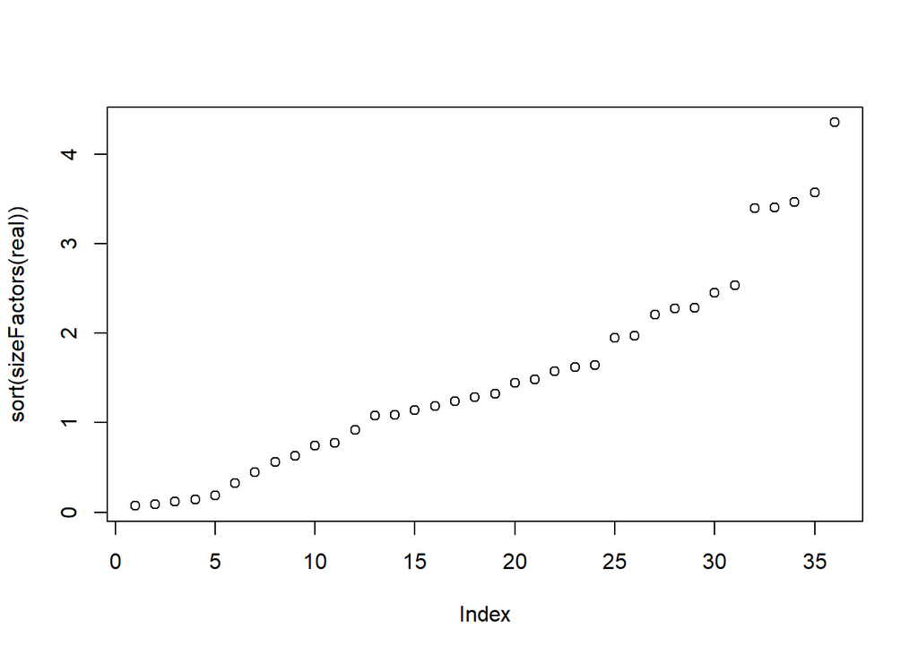

```r
real=newCountDataSet(countData,conditions)
real=estimateSizeFactors(real)
plot(sort(sizeFactors(real)))
```

```r
cds=estimateDispersions(real,method="blind")
vsdBlind=varianceStabilizingTransformation(cds)

#arrayQualityMetrics(vsdBlind,intgroup=c("treat"), force=TRUE)
```

Based on the arrayQualityMetrics, we determined that there are 5 outliers in our dataset. These samples are b37_10_7.5_4, b37_24_7.5_2, b37_24_7.5_4, b37_4_8_2, and b37_4_8_4.

```r
#Unloads DESeq before loading DESeq2 since the packages conflict
detach("package:DESeq", unload=TRUE)
#Load additional packages and filter data
library(DESeq2) #packageVersion("DESeq2"); citation("DESeq2")
```

```r
library(ggplot2) #packageVersion("ggplot2"); citation("ggplot2")
library(dplyr) #packageVersion("dplyr"); citation("dplyr")
library(RColorBrewer) #packageVersion("RColorBrewer"); citation("RColorBrewer")
library(gplots) #packageVersion("gplots"); citation("gplots")
library(pheatmap) #packageVersion("pheatmap"); citation("pheatmap")
library(vegan) #packageVersion("vegan"); citation("vegan")
library(ggrepel) #packageVersion("ggrepel"); citation("ggrepel")
library(tidyverse) #packageVersion("tidyverse"); citation("tidyverse")
library(adegenet) #packageVersion("adegenet"); citation("adegenet")
library(WGCNA) #packageVersion("WGCNA"); citation("WGCNA")
#read in counts (old data pre-filtered)
countData <- read.table("B37_counts_newtranscriptome.txt")
head(countData)
```

[output not shown]

[output cut: 197 more lines]

```
## TRINITY_DN10015_c0_g1                               0
##                       b37_4_8_3.fastq.trim.sam.counts
## TRINITY_DN0_c0_g1                                   1
## TRINITY_DN10003_c0_g1                               0
## TRINITY_DN10006_c0_g1                               0
## TRINITY_DN10007_c0_g1                               0
## TRINITY_DN10013_c0_g1                               1
## TRINITY_DN10015_c0_g1                               0
##                       b37_4_8_4.fastq.trim.sam.counts
## TRINITY_DN0_c0_g1                                   0
## TRINITY_DN10003_c0_g1                               0
## TRINITY_DN10006_c0_g1                               0
## TRINITY_DN10007_c0_g1                               0
## TRINITY_DN10013_c0_g1                               0
## TRINITY_DN10015_c0_g1                               0
```

```r
length(countData[,1])
```

```
## [1] 26660
```

```r
#26660

names(countData)=sub(".fastq.trim.sam.counts","",names(countData))
names(countData)
```

```
##  [1] "b37_0_8_1"    "b37_0_8_2"    "b37_0_8_3"    "b37_0_8_4"
##  [5] "b37_10_7.5_1" "b37_10_7.5_2" "b37_10_7.5_3" "b37_10_7.5_4"
##  [9] "b37_10_8_1"   "b37_10_8_2"   "b37_10_8_3"   "b37_10_8_4"
## [13] "b37_24_7.5_1" "b37_24_7.5_2" "b37_24_7.5_3" "b37_24_7.5_4"
## [17] "b37_24_8_1"   "b37_24_8_2"   "b37_24_8_3"   "b37_24_8_4"
## [21] "b37_48_7.5_1" "b37_48_7.5_2" "b37_48_7.5_3" "b37_48_7.5_4"
## [25] "b37_48_8_1"   "b37_48_8_2"   "b37_48_8_3"   "b37_48_8_4"
## [29] "b37_4_7.5_1"  "b37_4_7.5_2"  "b37_4_7.5_3"  "b37_4_7.5_4"
## [33] "b37_4_8_1"    "b37_4_8_2"    "b37_4_8_3"    "b37_4_8_4"
```

```r
#row.names(countData)=sub("", "isogroup", rownames(countData))
names(countData)
```

```
##  [1] "b37_0_8_1"    "b37_0_8_2"    "b37_0_8_3"    "b37_0_8_4"
##  [5] "b37_10_7.5_1" "b37_10_7.5_2" "b37_10_7.5_3" "b37_10_7.5_4"
##  [9] "b37_10_8_1"   "b37_10_8_2"   "b37_10_8_3"   "b37_10_8_4"
## [13] "b37_24_7.5_1" "b37_24_7.5_2" "b37_24_7.5_3" "b37_24_7.5_4"
## [17] "b37_24_8_1"   "b37_24_8_2"   "b37_24_8_3"   "b37_24_8_4"
## [21] "b37_48_7.5_1" "b37_48_7.5_2" "b37_48_7.5_3" "b37_48_7.5_4"
## [25] "b37_48_8_1"   "b37_48_8_2"   "b37_48_8_3"   "b37_48_8_4"
## [29] "b37_4_7.5_1"  "b37_4_7.5_2"  "b37_4_7.5_3"  "b37_4_7.5_4"
## [33] "b37_4_8_1"    "b37_4_8_2"    "b37_4_8_3"    "b37_4_8_4"
```

```r
#removing outlier samples (generally ones that failed to sequence)
countData$b37_10_7.5_4 <- NULL
countData$b37_24_7.5_2 <- NULL
countData$b37_24_7.5_4 <- NULL
countData$b37_4_8_2 <- NULL
countData$b37_4_8_4 <- NULL

totalCounts=colSums(countData)
totalCounts
```

```
##    b37_0_8_1    b37_0_8_2    b37_0_8_3    b37_0_8_4 b37_10_7.5_1
##       402011       437684       407762       126365       377236
## b37_10_7.5_2 b37_10_7.5_3   b37_10_8_1   b37_10_8_2   b37_10_8_3
##       522103       621347       223739       225729       260243
##   b37_10_8_4 b37_24_7.5_1 b37_24_7.5_3   b37_24_8_1   b37_24_8_2
##       587962       306236       360527       178560       554924
##   b37_24_8_3   b37_24_8_4 b37_48_7.5_1 b37_48_7.5_2 b37_48_7.5_3
##       139452       891746       609382      1235041       178275
## b37_48_7.5_4   b37_48_8_1   b37_48_8_2   b37_48_8_3   b37_48_8_4
##       297157       443670       917558       289920       620377
##  b37_4_7.5_1  b37_4_7.5_2  b37_4_7.5_3  b37_4_7.5_4    b37_4_8_1
##       605458       916263       314277       324889       926678
##    b37_4_8_3
##        94004
```

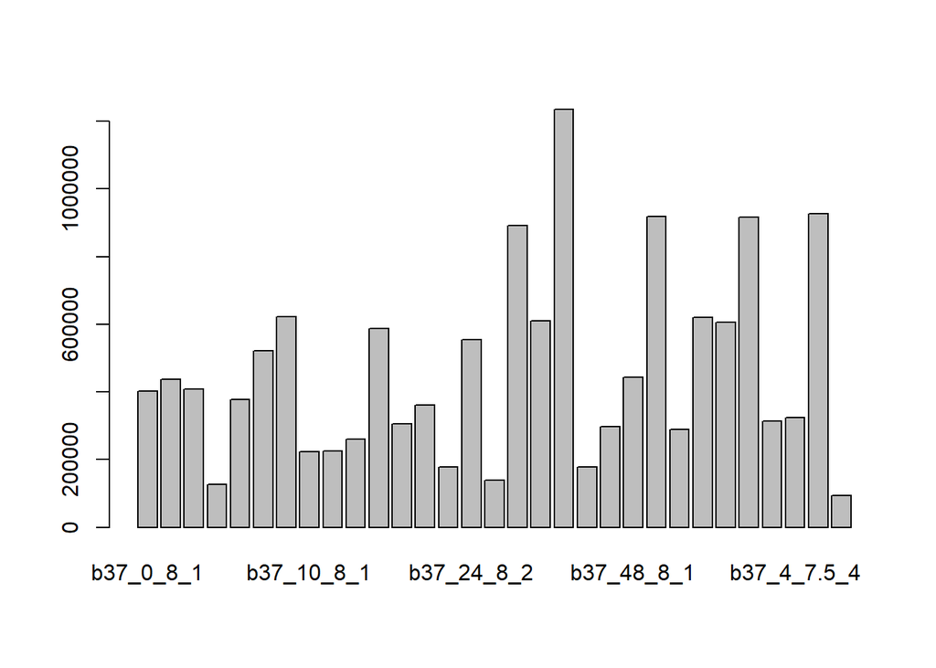

```r
barplot(totalCounts)
```

```r
#    b37_0_8_1    b37_0_8_2    b37_0_8_3    b37_0_8_4 b37_10_7.5_1
#       402011       437684       407762       126365       377236
# b37_10_7.5_2 b37_10_7.5_3   b37_10_8_1   b37_10_8_2   b37_10_8_3
#       522103       621347       223739       225729       260243
#   b37_10_8_4 b37_24_7.5_1 b37_24_7.5_3   b37_24_8_1   b37_24_8_2
#       587962       306236       360527       178560       554924
#   b37_24_8_3   b37_24_8_4 b37_48_7.5_1 b37_48_7.5_2 b37_48_7.5_3
#       139452       891746       609382      1235041       178275
# b37_48_7.5_4   b37_48_8_1   b37_48_8_2   b37_48_8_3   b37_48_8_4
#       297157       443670       917558       289920       620377
#  b37_4_7.5_1  b37_4_7.5_2  b37_4_7.5_3  b37_4_7.5_4    b37_4_8_1
#       605458       916263       314277       324889       926678
#    b37_4_8_3
#        94004

min(totalCounts) #94,004
```

```
## [1] 94004
```

```r
max(totalCounts)  # 1,235,041
```

```
## [1] 1235041
```

```r
#Remove day 0 data since it can't be compared between treatments (only pH 8 treatment available)
countData$b37_0_8_1 <- NULL
countData$b37_0_8_2 <- NULL
countData$b37_0_8_3 <- NULL
countData$b37_0_8_4 <- NULL

treat=c( "pH7.5", "pH7.5", "pH7.5","pH8", "pH8", "pH8", "pH8", "pH7.5", "pH7.5","pH8", "pH8", "pH8", "pH8","pH7.5", "pH7.5", "pH7.5", "pH7.5","pH8", "pH8", "pH8", "pH8","pH7.5", "pH7.5", "pH7.5", "pH7.5","pH8", "pH8")
hour=as.factor(c( "10", "10", "10", "10", "10", "10", "10", "24", "24", "24", "24", "24", "24","48", "48", "48","48", "48", "48", "48", "48", "4","4", "4", "4", "4", "4"))
```

Total counts between samples were variable and ranged from 94,004 to 1,235,041.

```r
#Subset data into time points
g=data.frame(treat, hour)
g
```

```
##    treat hour
## 1  pH7.5   10
## 2  pH7.5   10
## 3  pH7.5   10
## 4    pH8   10
## 5    pH8   10
## 6    pH8   10
## 7    pH8   10
## 8  pH7.5   24
## 9  pH7.5   24
## 10   pH8   24
## 11   pH8   24
## 12   pH8   24
## 13   pH8   24
## 14 pH7.5   48
## 15 pH7.5   48
## 16 pH7.5   48
## 17 pH7.5   48
## 18   pH8   48
## 19   pH8   48
## 20   pH8   48
## 21   pH8   48
## 22 pH7.5    4
## 23 pH7.5    4
## 24 pH7.5    4
## 25 pH7.5    4
## 26   pH8    4
## 27   pH8    4
```

```r
colData<- g
colData4 = colData[colData$hour == 4,]
colData10 = colData[colData$hour == 10,]
colData24 = colData[colData$hour == 24,]
colData48 = colData[colData$hour == 48,]


dds<-DESeqDataSetFromMatrix(countData=countData, colData=colData, design=~treat+hour+treat*hour )
head(dds)
```

```
## class: DESeqDataSet
## dim: 6 27
## metadata(1): version
## assays(1): counts
## rownames(6): TRINITY_DN0_c0_g1 TRINITY_DN10003_c0_g1 ...
##   TRINITY_DN10013_c0_g1 TRINITY_DN10015_c0_g1
## rowData names(0):
## colnames(27): b37_10_7.5_1 b37_10_7.5_2 ... b37_4_8_1 b37_4_8_3
## colData names(2): treat hour
```

```r
dds4 = dds[,colData$hour == 4]
head(dds4)
```

```
## class: DESeqDataSet
## dim: 6 6
## metadata(1): version
## assays(1): counts
## rownames(6): TRINITY_DN0_c0_g1 TRINITY_DN10003_c0_g1 ...
##   TRINITY_DN10013_c0_g1 TRINITY_DN10015_c0_g1
## rowData names(0):
## colnames(6): b37_4_7.5_1 b37_4_7.5_2 ... b37_4_8_1 b37_4_8_3
## colData names(2): treat hour
```

```r
dds10 = dds[,colData$hour == 10]
head(dds10)
```

```
## class: DESeqDataSet
## dim: 6 7
## metadata(1): version
## assays(1): counts
## rownames(6): TRINITY_DN0_c0_g1 TRINITY_DN10003_c0_g1 ...
##   TRINITY_DN10013_c0_g1 TRINITY_DN10015_c0_g1
## rowData names(0):
## colnames(7): b37_10_7.5_1 b37_10_7.5_2 ... b37_10_8_3 b37_10_8_4
## colData names(2): treat hour
```

```r
dds24 = dds[,colData$hour == 24]
head(dds24)
```

```
## class: DESeqDataSet
## dim: 6 6
## metadata(1): version
## assays(1): counts
## rownames(6): TRINITY_DN0_c0_g1 TRINITY_DN10003_c0_g1 ...
##   TRINITY_DN10013_c0_g1 TRINITY_DN10015_c0_g1
## rowData names(0):
## colnames(6): b37_24_7.5_1 b37_24_7.5_3 ... b37_24_8_3 b37_24_8_4
## colData names(2): treat hour
```

```r
dds48 = dds[,colData$hour == 48]
head(dds48)
```

```
## class: DESeqDataSet
## dim: 6 8
## metadata(1): version
## assays(1): counts
## rownames(6): TRINITY_DN0_c0_g1 TRINITY_DN10003_c0_g1 ...
##   TRINITY_DN10013_c0_g1 TRINITY_DN10015_c0_g1
## rowData names(0):
## colnames(8): b37_48_7.5_1 b37_48_7.5_2 ... b37_48_8_3 b37_48_8_4
## colData names(2): treat hour
```

```r
design(dds4) = ~treat
design(dds10) = ~treat
design(dds24) = ~treat
design(dds48) = ~treat

dds<-DESeq(dds)
dds4<-DESeq(dds4)
dds10<-DESeq(dds10)
dds24<-DESeq(dds24)
dds48<-DESeq(dds48)
# estimating size factors
# estimating dispersions
# gene-wise dispersion estimates
# mean-dispersion relationship
# final dispersion estimates
# fitting model and testing

head(dds)
```

```
## class: DESeqDataSet
## dim: 6 27
## metadata(1): version
## assays(4): counts mu H cooks
## rownames(6): TRINITY_DN0_c0_g1 TRINITY_DN10003_c0_g1 ...
##   TRINITY_DN10013_c0_g1 TRINITY_DN10015_c0_g1
## rowData names(46): baseMean baseVar ... deviance maxCooks
## colnames(27): b37_10_7.5_1 b37_10_7.5_2 ... b37_4_8_1 b37_4_8_3
## colData names(3): treat hour sizeFactor
```

```r
res<- results(dds)
head(dds4)
```

```
## class: DESeqDataSet
## dim: 6 6
## metadata(1): version
## assays(4): counts mu H cooks
## rownames(6): TRINITY_DN0_c0_g1 TRINITY_DN10003_c0_g1 ...
##   TRINITY_DN10013_c0_g1 TRINITY_DN10015_c0_g1
## rowData names(22): baseMean baseVar ... deviance maxCooks
## colnames(6): b37_4_7.5_1 b37_4_7.5_2 ... b37_4_8_1 b37_4_8_3
## colData names(3): treat hour sizeFactor
```

```r
res4<- results(dds4)
head(dds10)
```

```
## class: DESeqDataSet
## dim: 6 7
## metadata(1): version
## assays(4): counts mu H cooks
## rownames(6): TRINITY_DN0_c0_g1 TRINITY_DN10003_c0_g1 ...
##   TRINITY_DN10013_c0_g1 TRINITY_DN10015_c0_g1
## rowData names(22): baseMean baseVar ... deviance maxCooks
## colnames(7): b37_10_7.5_1 b37_10_7.5_2 ... b37_10_8_3 b37_10_8_4
## colData names(3): treat hour sizeFactor
```

```r
res10<- results(dds10)
head(dds24)
```

```
## class: DESeqDataSet
## dim: 6 6
## metadata(1): version
## assays(4): counts mu H cooks
## rownames(6): TRINITY_DN0_c0_g1 TRINITY_DN10003_c0_g1 ...
##   TRINITY_DN10013_c0_g1 TRINITY_DN10015_c0_g1
## rowData names(22): baseMean baseVar ... deviance maxCooks
## colnames(6): b37_24_7.5_1 b37_24_7.5_3 ... b37_24_8_3 b37_24_8_4
## colData names(3): treat hour sizeFactor
```

```r
res24<- results(dds24)
head(dds48)
```

```
## class: DESeqDataSet
## dim: 6 8
## metadata(1): version
## assays(4): counts mu H cooks
## rownames(6): TRINITY_DN0_c0_g1 TRINITY_DN10003_c0_g1 ...
##   TRINITY_DN10013_c0_g1 TRINITY_DN10015_c0_g1
## rowData names(22): baseMean baseVar ... deviance maxCooks
## colnames(8): b37_48_7.5_1 b37_48_7.5_2 ... b37_48_8_3 b37_48_8_4
## colData names(3): treat hour sizeFactor
```

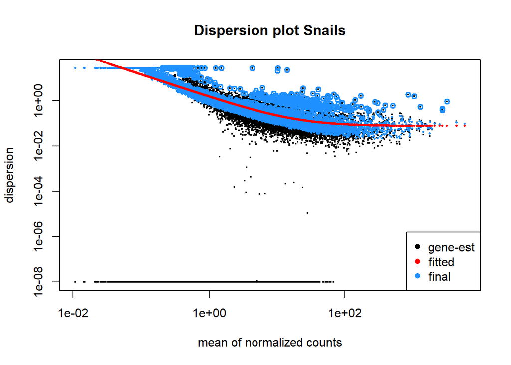

```r
res48<- results(dds48)

#Look at dispersions plot
plotDispEsts(dds, main="Dispersion plot Snails")
```

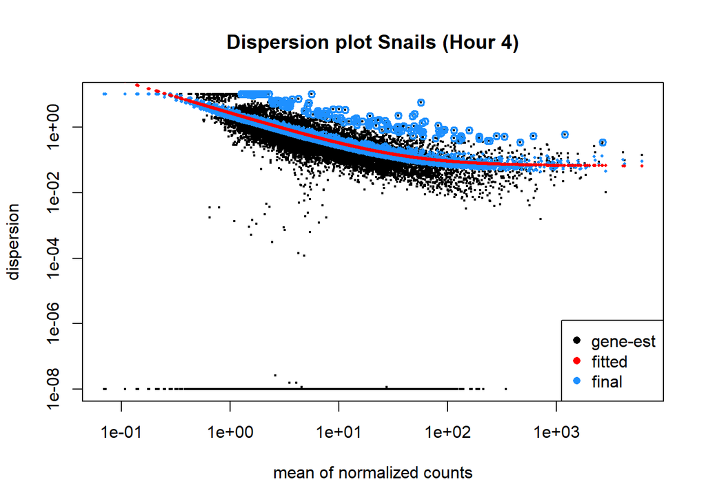

```r
plotDispEsts(dds4, main="Dispersion plot Snails (Hour 4)")
```

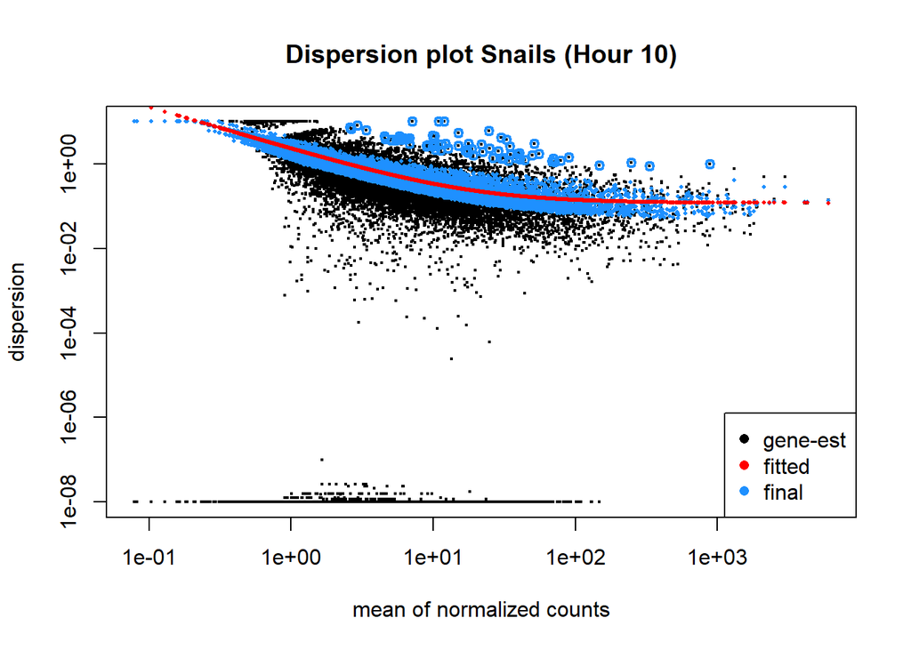

```r
plotDispEsts(dds10, main="Dispersion plot Snails (Hour 10)")
```

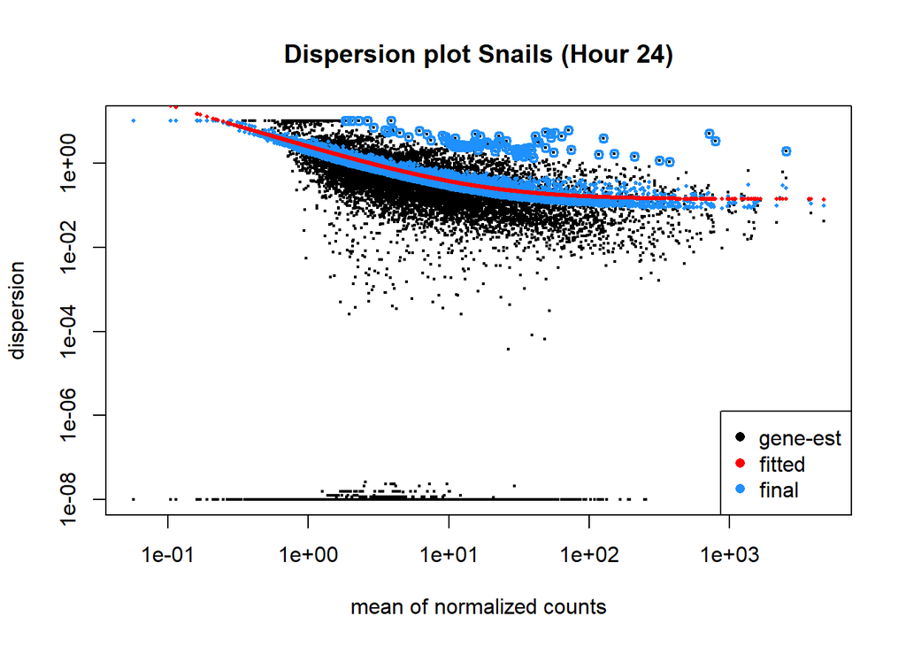

```r
plotDispEsts(dds24, main="Dispersion plot Snails (Hour 24)")
```

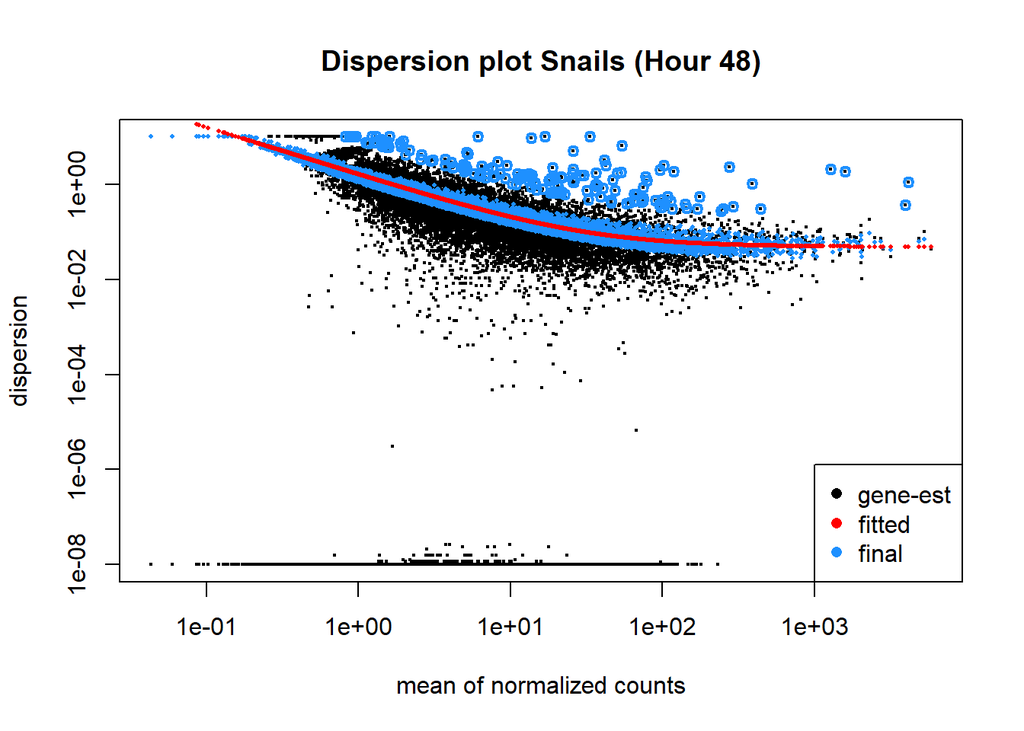

```r
plotDispEsts(dds48, main="Dispersion plot Snails (Hour 48)")
```

The dispersion plots use a shrinking method to reduce false positives in the differential expression analysis. Black dots represent genes, the red line is a model fit to the genes, and the blue dots are the genes after they’ve been processed through the shrinking method. Genes with low dispersion estimates are shrunken towards the curve and are the output for differential expression testing. Dispersion estimates slightly above the curve are also shrunken, but those with extreme high dispersion are not. These genes, shown as surrounded by blue circles, likely do not follow the model assumptions and have higher variability. Shrinking them would only lead to false positives. They are not usually outputted for differential gene expression testing.

```r
###Assess Pco2 treatments: pH8 vs pH7.5
#Hour 4
respH75.4 <- results(dds4, contrast=c("treat","pH7.5","pH8"))
table(respH75.4$padj<.1)
```

```
##
## FALSE  TRUE
## 25787     2
```

```r
table(respH75.4$padj<.05)
```

```
##
## FALSE
## 25789
```

```r
table(respH75.4$padj<.01)
```

```
##
## FALSE
## 25789
```

```r
# 0.1=2/25789
# 0.05=0/25789
# 0.01=0/25789
summary(respH75.4)
```

```
##
## out of 25789 with nonzero total read count
## adjusted p-value < 0.1
## LFC > 0 (up)       : 1, 0.0039%
## LFC < 0 (down)     : 1, 0.0039%
## outliers [1]       : 0, 0%
## low counts [2]     : 0, 0%
## (mean count < 0)
## [1] see 'cooksCutoff' argument of ?results
## [2] see 'independentFiltering' argument of ?results
```

```r
#LFC>0: 1, 0.0039%
#LFC<0: 1, 0.0039%
#Outliers: 0, 0%
#Low counts: 0, 0%

nrow(respH75.4[respH75.4$padj<0.05 & !is.na(respH75.4$padj),])
```

```
## [1] 0
```

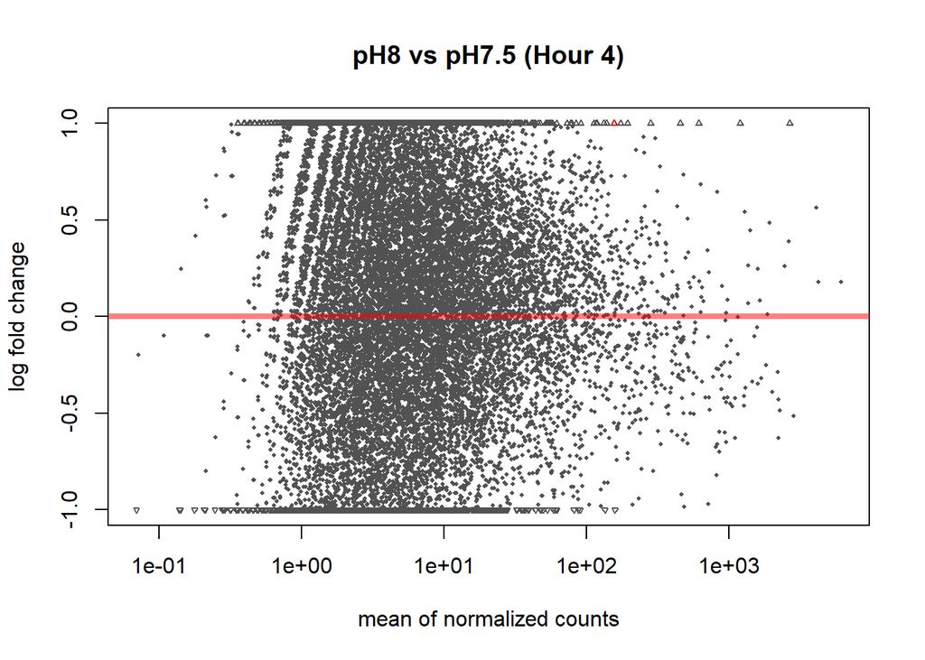

```r
# Num significantly differentially expressed genes excluding the no/low count genes   #0

#scatterplot of logarithmic fold changes versus the mean of normalized counts
plotMA(respH75.4, main="pH8 vs pH7.5 (Hour 4)", ylim=c(-1,1))
```

```r
results75.4 <- as.data.frame(respH75.4)
head(results75.4)
```

```
##                       baseMean log2FoldChange    lfcSE       stat
## TRINITY_DN0_c0_g1     3.343140      0.5487160 1.332925  0.4116631
## TRINITY_DN10003_c0_g1 1.110746      0.8659277 2.130932  0.4063611
## TRINITY_DN10006_c0_g1 1.045047      0.6672113 2.201087  0.3031280
## TRINITY_DN10007_c0_g1 1.636762     -0.4153580 2.012468 -0.2063924
## TRINITY_DN10013_c0_g1 3.233520     -1.3247089 1.232348 -1.0749470
## TRINITY_DN10015_c0_g1 0.000000             NA       NA         NA
##                          pvalue      padj
## TRINITY_DN0_c0_g1     0.6805864 0.9998843
## TRINITY_DN10003_c0_g1 0.6844773 0.9998843
## TRINITY_DN10006_c0_g1 0.7617923 0.9998843
## TRINITY_DN10007_c0_g1 0.8364844 0.9998843
## TRINITY_DN10013_c0_g1 0.2823984 0.9998843
## TRINITY_DN10015_c0_g1        NA        NA
```

```r
nrow(respH75.4[respH75.4$padj<0.1 & respH75.4$log2FoldChange > 0 & !is.na(respH75.4$padj),])
```

```
## [1] 1
```

```r
nrow(respH75.4[respH75.4$padj<0.1 & respH75.4$log2FoldChange < -0 & !is.na(respH75.4$padj),])
```

```
## [1] 1
```

```r
#UP in 7.5 (Hour 4): 1
#DOWN in 7.5 (Hour 4): 1

write.table(respH75.4, file="b37_7.5.4_2017.txt", quote=F, sep="\t")

cp4 <- read.table("b37_7.5.4_2017.txt")
head(cp4)
```

```
##                       baseMean log2FoldChange    lfcSE       stat
## TRINITY_DN0_c0_g1     3.343140      0.5487160 1.332925  0.4116631
## TRINITY_DN10003_c0_g1 1.110746      0.8659277 2.130932  0.4063611
## TRINITY_DN10006_c0_g1 1.045047      0.6672113 2.201087  0.3031280
## TRINITY_DN10007_c0_g1 1.636762     -0.4153580 2.012468 -0.2063924
## TRINITY_DN10013_c0_g1 3.233520     -1.3247089 1.232348 -1.0749470
## TRINITY_DN10015_c0_g1 0.000000             NA       NA         NA
##                          pvalue      padj
## TRINITY_DN0_c0_g1     0.6805864 0.9998843
## TRINITY_DN10003_c0_g1 0.6844773 0.9998843
## TRINITY_DN10006_c0_g1 0.7617923 0.9998843
## TRINITY_DN10007_c0_g1 0.8364844 0.9998843
## TRINITY_DN10013_c0_g1 0.2823984 0.9998843
## TRINITY_DN10015_c0_g1        NA        NA
```

```
##                         baseMean log2FoldChange    lfcSE       stat
## TRINITY_DN0_c0_g1     1.74120392      0.5487160 1.332925  0.4116631
## TRINITY_DN10003_c0_g1 0.15152854      0.8659277 2.130932  0.4063611
## TRINITY_DN10006_c0_g1 0.06356771      0.6672113 2.201087  0.3031280
## TRINITY_DN10007_c0_g1 0.71084481     -0.4153580 2.012468 -0.2063924
## TRINITY_DN10013_c0_g1 1.69310538     -1.3247089 1.232348 -1.0749470
## TRINITY_DN10015_c0_g1       -Inf             NA       NA         NA
##                          pvalue      padj dotcol
## TRINITY_DN0_c0_g1     0.6805864 0.9998843  black
## TRINITY_DN10003_c0_g1 0.6844773 0.9998843  black
## TRINITY_DN10006_c0_g1 0.7617923 0.9998843  black
## TRINITY_DN10007_c0_g1 0.8364844 0.9998843  black
## TRINITY_DN10013_c0_g1 0.2823984 0.9998843  black
## TRINITY_DN10015_c0_g1        NA        NA   <NA>
```

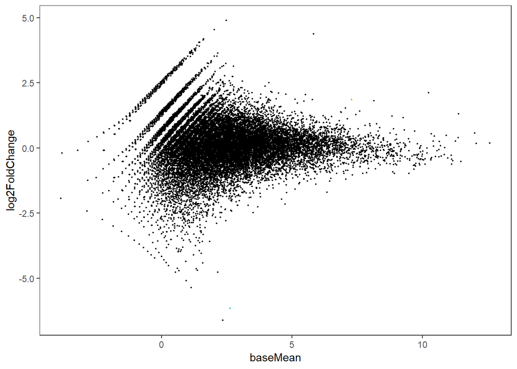

```r
MAttPlot <- function(df) {
  df$dotcol <- ifelse(df$log2FoldChange > 0 & df$padj < 0.1, 'darkorange',
                      ifelse(df$log2FoldChange < 0 & df$padj < 0.1, 'cyan3', 'black'))
  df$baseMean <- log2(df$baseMean)
  print(head(df))
  gg <- ggplot(df, aes(baseMean, log2FoldChange)) +
    geom_point(size = .3, color = df$dotcol) +
    theme_bw() +
    theme(panel.grid = element_blank())
  print(gg)
}

MAttPlot(cp4)
```

```r
#orange dots = upregulated, blue dots = downregulated

#Hour 10
respH75.10 <- results(dds10, contrast=c("treat","pH7.5","pH8"))
table(respH75.10$padj<.1)
```

```
##
## FALSE
## 25814
```

```r
table(respH75.10$padj<.05)
```

```
##
## FALSE
## 25814
```

```r
table(respH75.10$padj<.01)
```

```
##
## FALSE
## 25814
```

```r
# 0.1=0/25814
# 0.05=0/25814
# 0.01=0/25814
summary(respH75.10)
```

```
##
## out of 25817 with nonzero total read count
## adjusted p-value < 0.1
## LFC > 0 (up)       : 0, 0%
## LFC < 0 (down)     : 0, 0%
## outliers [1]       : 3, 0.012%
## low counts [2]     : 0, 0%
## (mean count < 0)
## [1] see 'cooksCutoff' argument of ?results
## [2] see 'independentFiltering' argument of ?results
```

```r
#LFC>0: 0, 0%
#LFC<0: 0, 0%
#Outliers: 3, 0.012%
#Low counts: 0, 0%

nrow(respH75.10[respH75.10$padj<0.05 & !is.na(respH75.10$padj),])
```

```
## [1] 0
```

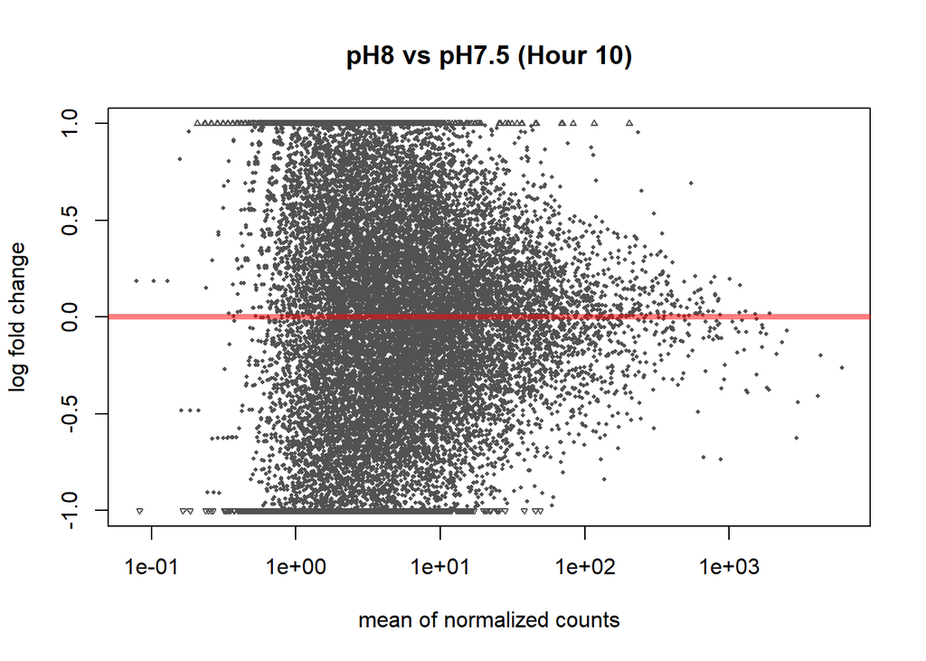

```r
# Num significantly differentially expressed genes excluding the no/low count genes   #0

plotMA(respH75.10, main="pH8 vs pH7.5 (Hour 10)", ylim=c(-1,1))
```

```r
results75.10 <- as.data.frame(respH75.10)
head(results75.10)
```

```
##                        baseMean log2FoldChange    lfcSE       stat
## TRINITY_DN0_c0_g1     1.5167429      0.2741076 1.369350  0.2001735
## TRINITY_DN10003_c0_g1 0.9583430     -1.6009923 1.979918 -0.8086155
## TRINITY_DN10006_c0_g1 2.3448862      0.2821325 1.229190  0.2295271
## TRINITY_DN10007_c0_g1 0.7915298     -0.6509145 2.238866 -0.2907340
## TRINITY_DN10013_c0_g1 3.5362820      0.1233474 1.138559  0.1083364
## TRINITY_DN10015_c0_g1 0.0000000             NA       NA         NA
##                          pvalue      padj
## TRINITY_DN0_c0_g1     0.8413449 0.9998577
## TRINITY_DN10003_c0_g1 0.4187363 0.9998577
## TRINITY_DN10006_c0_g1 0.8184592 0.9998577
## TRINITY_DN10007_c0_g1 0.7712547 0.9998577
## TRINITY_DN10013_c0_g1 0.9137288 0.9998577
## TRINITY_DN10015_c0_g1        NA        NA
```

```r
nrow(respH75.10[respH75.10$padj<0.1 & respH75.10$log2FoldChange > 0 & !is.na(respH75.10$padj),])
```

```
## [1] 0
```

```r
nrow(respH75.10[respH75.10$padj<0.1 & respH75.10$log2FoldChange < -0 & !is.na(respH75.10$padj),])
```

```
## [1] 0
```

```r
#UP in 7.5 (Hour 10): 0
#DOWN in 7.5 (Hour 10): 0

write.table(respH75.10, file="b37_7.5.10_2017.txt", quote=F, sep="\t")

cp10 <- read.table("b37_7.5.10_2017.txt")
head(cp10)
```

```
##                        baseMean log2FoldChange    lfcSE       stat
## TRINITY_DN0_c0_g1     1.5167429      0.2741076 1.369350  0.2001735
## TRINITY_DN10003_c0_g1 0.9583430     -1.6009923 1.979918 -0.8086155
## TRINITY_DN10006_c0_g1 2.3448862      0.2821325 1.229190  0.2295271
## TRINITY_DN10007_c0_g1 0.7915298     -0.6509145 2.238866 -0.2907340
## TRINITY_DN10013_c0_g1 3.5362820      0.1233474 1.138559  0.1083364
## TRINITY_DN10015_c0_g1 0.0000000             NA       NA         NA
##                          pvalue      padj
## TRINITY_DN0_c0_g1     0.8413449 0.9998577
## TRINITY_DN10003_c0_g1 0.4187363 0.9998577
## TRINITY_DN10006_c0_g1 0.8184592 0.9998577
## TRINITY_DN10007_c0_g1 0.7712547 0.9998577
## TRINITY_DN10013_c0_g1 0.9137288 0.9998577
## TRINITY_DN10015_c0_g1        NA        NA
```

```
##                          baseMean log2FoldChange    lfcSE       stat
## TRINITY_DN0_c0_g1      0.60097655      0.2741076 1.369350  0.2001735
## TRINITY_DN10003_c0_g1 -0.06138594     -1.6009923 1.979918 -0.8086155
## TRINITY_DN10006_c0_g1  1.22951792      0.2821325 1.229190  0.2295271
## TRINITY_DN10007_c0_g1 -0.33728445     -0.6509145 2.238866 -0.2907340
## TRINITY_DN10013_c0_g1  1.82223334      0.1233474 1.138559  0.1083364
## TRINITY_DN10015_c0_g1        -Inf             NA       NA         NA
##                          pvalue      padj dotcol
## TRINITY_DN0_c0_g1     0.8413449 0.9998577  black
## TRINITY_DN10003_c0_g1 0.4187363 0.9998577  black
## TRINITY_DN10006_c0_g1 0.8184592 0.9998577  black
## TRINITY_DN10007_c0_g1 0.7712547 0.9998577  black
## TRINITY_DN10013_c0_g1 0.9137288 0.9998577  black
## TRINITY_DN10015_c0_g1        NA        NA   <NA>
```

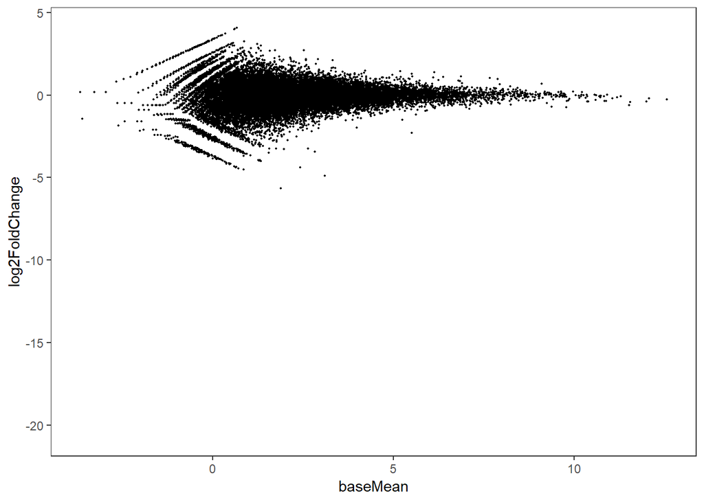

```r
MAttPlot(cp10)
```

```r
#orange dots = upregulated, blue dots = downregulated

#Hour 24
respH75.24 <- results(dds24, contrast=c("treat","pH7.5","pH8"))
table(respH75.24$padj<.1)
```

```
##
## FALSE
## 25690
```

```r
table(respH75.24$padj<.05)
```

```
##
## FALSE
## 25690
```

```r
table(respH75.24$padj<.01)
```

```
##
## FALSE
## 25690
```

```r
# 0.1=0/25690
# 0.05=0/25690
# 0.01=0/25690
summary(respH75.24)
```

```
##
## out of 25691 with nonzero total read count
## adjusted p-value < 0.1
## LFC > 0 (up)       : 0, 0%
## LFC < 0 (down)     : 0, 0%
## outliers [1]       : 1, 0.0039%
## low counts [2]     : 0, 0%
## (mean count < 0)
## [1] see 'cooksCutoff' argument of ?results
## [2] see 'independentFiltering' argument of ?results
```

```r
#LFC>0: 0, 0%
#LFC<0: 0, 0%
#Outliers: 1, 0.0039%
#Low counts: 0, 0%

nrow(respH75.24[respH75.24$padj<0.05 & !is.na(respH75.24$padj),])
```

```
## [1] 0
```

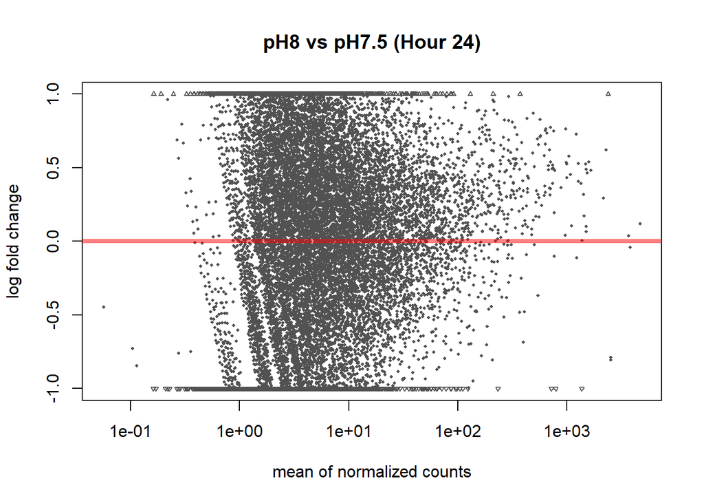

```r
# Num significantly differentially expressed genes excluding the no/low count genes   #0

plotMA(respH75.24, main="pH8 vs pH7.5 (Hour 24)", ylim=c(-1,1))
```

```r
results75.24 <- as.data.frame(respH75.24)
head(results75.24)
```

```
##                         baseMean log2FoldChange    lfcSE        stat
## TRINITY_DN0_c0_g1     1.14560320    -3.05114118 2.337825 -1.30511972
## TRINITY_DN10003_c0_g1 0.70209560     0.79506981 2.539863  0.31303644
## TRINITY_DN10006_c0_g1 1.53291385    -0.06205319 1.715490 -0.03617229
## TRINITY_DN10007_c0_g1 0.27620616     0.56204271 3.990919  0.14083039
## TRINITY_DN10013_c0_g1 2.70552289     0.95886892 1.309936  0.73199695
## TRINITY_DN10015_c0_g1 0.05665212    -0.44703978 4.316682 -0.10356098
##                          pvalue      padj
## TRINITY_DN0_c0_g1     0.1918521 0.9998486
## TRINITY_DN10003_c0_g1 0.7542530 0.9998486
## TRINITY_DN10006_c0_g1 0.9711450 0.9998486
## TRINITY_DN10007_c0_g1 0.8880039 0.9998486
## TRINITY_DN10013_c0_g1 0.4641704 0.9998486
## TRINITY_DN10015_c0_g1 0.9175178 0.9998486
```

```r
nrow(respH75.24[respH75.24$padj<0.1 & respH75.24$log2FoldChange > 0 & !is.na(respH75.24$padj),])
```

```
## [1] 0
```

```r
nrow(respH75.24[respH75.24$padj<0.1 & respH75.24$log2FoldChange < -0 & !is.na(respH75.24$padj),])
```

```
## [1] 0
```

```r
#UP in 7.5 (Hour 24): 0
#DOWN in 7.5 (Hour 24): 0

write.table(respH75.24, file="b37_7.5.24_2017.txt", quote=F, sep="\t")

cp24 <- read.table("b37_7.5.24_2017.txt")
head(cp24)
```

```
##                         baseMean log2FoldChange    lfcSE        stat
## TRINITY_DN0_c0_g1     1.14560320    -3.05114118 2.337825 -1.30511972
## TRINITY_DN10003_c0_g1 0.70209560     0.79506981 2.539863  0.31303644
## TRINITY_DN10006_c0_g1 1.53291385    -0.06205319 1.715490 -0.03617229
## TRINITY_DN10007_c0_g1 0.27620616     0.56204271 3.990919  0.14083039
## TRINITY_DN10013_c0_g1 2.70552289     0.95886892 1.309936  0.73199695
## TRINITY_DN10015_c0_g1 0.05665212    -0.44703978 4.316682 -0.10356098
##                          pvalue      padj
## TRINITY_DN0_c0_g1     0.1918521 0.9998486
## TRINITY_DN10003_c0_g1 0.7542530 0.9998486
## TRINITY_DN10006_c0_g1 0.9711450 0.9998486
## TRINITY_DN10007_c0_g1 0.8880039 0.9998486
## TRINITY_DN10013_c0_g1 0.4641704 0.9998486
## TRINITY_DN10015_c0_g1 0.9175178 0.9998486
```

```
##                         baseMean log2FoldChange    lfcSE        stat
## TRINITY_DN0_c0_g1      0.1961074    -3.05114118 2.337825 -1.30511972
## TRINITY_DN10003_c0_g1 -0.5102606     0.79506981 2.539863  0.31303644
## TRINITY_DN10006_c0_g1  0.6162766    -0.06205319 1.715490 -0.03617229
## TRINITY_DN10007_c0_g1 -1.8561826     0.56204271 3.990919  0.14083039
## TRINITY_DN10013_c0_g1  1.4359074     0.95886892 1.309936  0.73199695
## TRINITY_DN10015_c0_g1 -4.1417262    -0.44703978 4.316682 -0.10356098
##                          pvalue      padj dotcol
## TRINITY_DN0_c0_g1     0.1918521 0.9998486  black
## TRINITY_DN10003_c0_g1 0.7542530 0.9998486  black
## TRINITY_DN10006_c0_g1 0.9711450 0.9998486  black
## TRINITY_DN10007_c0_g1 0.8880039 0.9998486  black
## TRINITY_DN10013_c0_g1 0.4641704 0.9998486  black
## TRINITY_DN10015_c0_g1 0.9175178 0.9998486  black
```

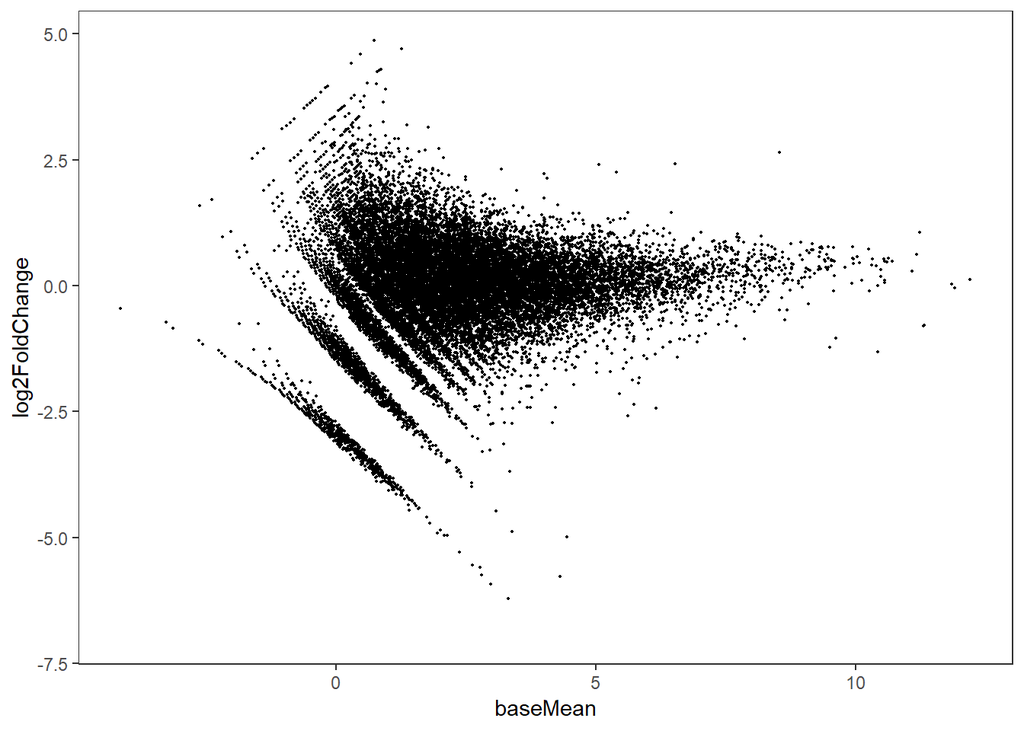

```r
MAttPlot(cp24)
```

```r
#orange dots = upregulated, blue dots = downregulated

#Hour 48
respH75.48 <- results(dds48, contrast=c("treat","pH7.5","pH8"))
table(respH75.48$padj<.1)
```

```
##
## FALSE  TRUE
## 15542    33
```

```r
table(respH75.48$padj<.05)
```

```
##
## FALSE  TRUE
## 15553    22
```

```r
table(respH75.48$padj<.01)
```

```
##
## FALSE  TRUE
## 15557    18
```

```r
# 0.1=33/15575
# 0.05=22/15575
# 0.01=18/15575
summary(respH75.48)
```

```
##
## out of 26269 with nonzero total read count
## adjusted p-value < 0.1
## LFC > 0 (up)       : 18, 0.069%
## LFC < 0 (down)     : 15, 0.057%
## outliers [1]       : 7, 0.027%
## low counts [2]     : 10687, 41%
## (mean count < 3)
## [1] see 'cooksCutoff' argument of ?results
## [2] see 'independentFiltering' argument of ?results
```

```r
#LFC>0: 18, 0.069%
#LFC<0: 15, 0.057%
#Outliers: 7, 0.027%
#Low counts: 10687, 41%

nrow(respH75.48[respH75.48$padj<0.05 & !is.na(respH75.48$padj),])
```

```
## [1] 22
```

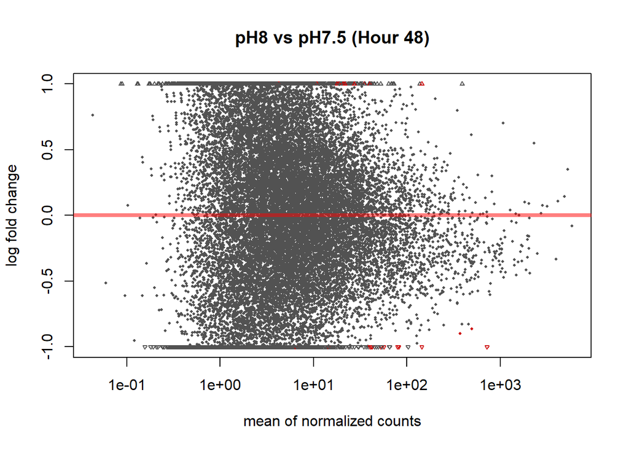

```r
# Num significantly differentially expressed genes excluding the no/low count genes   #22

#scatterplot of logarithmic fold changes versus the mean of normalized counts
plotMA(respH75.48, main="pH8 vs pH7.5 (Hour 48)", ylim=c(-1,1))
```

```r
results75.48 <- as.data.frame(respH75.48)
head(results75.48)
```

```
##                        baseMean log2FoldChange     lfcSE       stat
## TRINITY_DN0_c0_g1     2.0410893     -0.6640155 1.0590581 -0.6269868
## TRINITY_DN10003_c0_g1 2.4410278      3.5195155 1.2728076  2.7651590
## TRINITY_DN10006_c0_g1 2.8251214      0.4699077 0.9286928  0.5059884
## TRINITY_DN10007_c0_g1 0.4652091      1.5535144 2.2227819  0.6989055
## TRINITY_DN10013_c0_g1 3.6742435     -0.1769728 0.8359930 -0.2116917
## TRINITY_DN10015_c0_g1 0.0000000             NA        NA         NA
##                            pvalue      padj
## TRINITY_DN0_c0_g1     0.530667865        NA
## TRINITY_DN10003_c0_g1 0.005689505        NA
## TRINITY_DN10006_c0_g1 0.612864817 0.9983209
## TRINITY_DN10007_c0_g1 0.484611114        NA
## TRINITY_DN10013_c0_g1 0.832347532 0.9983209
## TRINITY_DN10015_c0_g1          NA        NA
```

```r
nrow(respH75.48[respH75.48$padj<0.1 & respH75.48$log2FoldChange > 0 & !is.na(respH75.48$padj),])
```

```
## [1] 18
```

```r
nrow(respH75.48[respH75.48$padj<0.1 & respH75.48$log2FoldChange < -0 & !is.na(respH75.48$padj),])
```

```
## [1] 15
```

```r
#UP in 7.5 (Hour 48): 18
#DOWN in 7.5 (Hour 48): 15

write.table(respH75.48, file="b37_7.5.48_2017.txt", quote=F, sep="\t")

cp48 <- read.table("b37_7.5.48_2017.txt")
head(cp48)
```

```
##                        baseMean log2FoldChange     lfcSE       stat
## TRINITY_DN0_c0_g1     2.0410893     -0.6640155 1.0590581 -0.6269868
## TRINITY_DN10003_c0_g1 2.4410278      3.5195155 1.2728076  2.7651590
## TRINITY_DN10006_c0_g1 2.8251214      0.4699077 0.9286928  0.5059884
## TRINITY_DN10007_c0_g1 0.4652091      1.5535144 2.2227819  0.6989055
## TRINITY_DN10013_c0_g1 3.6742435     -0.1769728 0.8359930 -0.2116917
## TRINITY_DN10015_c0_g1 0.0000000             NA        NA         NA
##                            pvalue      padj
## TRINITY_DN0_c0_g1     0.530667865        NA
## TRINITY_DN10003_c0_g1 0.005689505        NA
## TRINITY_DN10006_c0_g1 0.612864817 0.9983209
## TRINITY_DN10007_c0_g1 0.484611114        NA
## TRINITY_DN10013_c0_g1 0.832347532 0.9983209
## TRINITY_DN10015_c0_g1          NA        NA
```

```
##                        baseMean log2FoldChange     lfcSE       stat
## TRINITY_DN0_c0_g1      1.029339     -0.6640155 1.0590581 -0.6269868
## TRINITY_DN10003_c0_g1  1.287489      3.5195155 1.2728076  2.7651590
## TRINITY_DN10006_c0_g1  1.498313      0.4699077 0.9286928  0.5059884
## TRINITY_DN10007_c0_g1 -1.104049      1.5535144 2.2227819  0.6989055
## TRINITY_DN10013_c0_g1  1.877447     -0.1769728 0.8359930 -0.2116917
## TRINITY_DN10015_c0_g1      -Inf             NA        NA         NA
##                            pvalue      padj dotcol
## TRINITY_DN0_c0_g1     0.530667865        NA   <NA>
## TRINITY_DN10003_c0_g1 0.005689505        NA   <NA>
## TRINITY_DN10006_c0_g1 0.612864817 0.9983209  black
## TRINITY_DN10007_c0_g1 0.484611114        NA   <NA>
## TRINITY_DN10013_c0_g1 0.832347532 0.9983209  black
## TRINITY_DN10015_c0_g1          NA        NA   <NA>
```

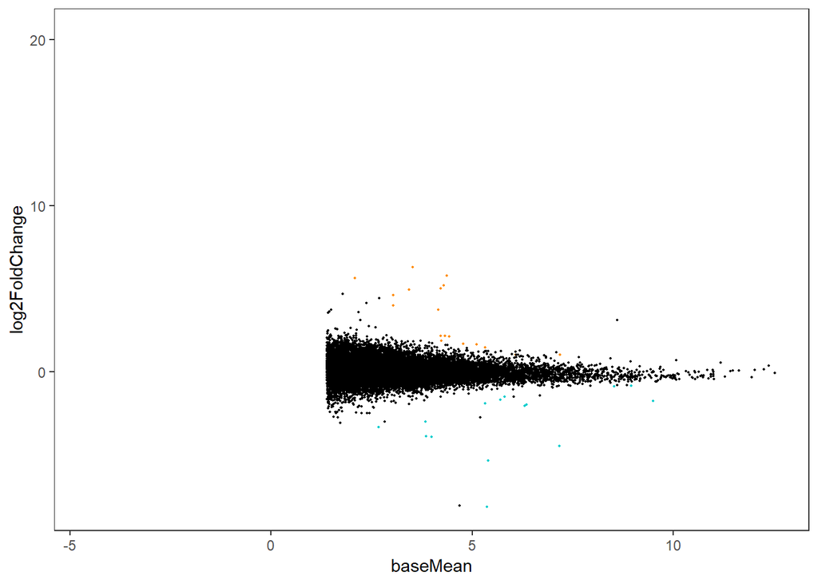

```r
MAttPlot(cp48)
```

```r
#orange dots = upregulated, blue dots = downregulated
```

The MA-plot shows log2 fold changes attributable to treatment. Points are red if the adjusted p-value is less than 0.1. Arrows at the top and bottom of the figure indicate points outside the margins of the plot.

The Mattplot is similar except it uses a base mean rather than mean of normalized counts. Orange dots are significantly upregulated and blue dots are significantly downregulated. We can see that 1 gene is differentially upregulated and 1 gene is differentially downregulated at pH 7.5 in comparison to pH 8.0 at 4 hours and 18 are upregulated and 15 are downregulated at 48 hours. There appear to be no differentially regulated genes at hours 10 or 24.

```r
##make the GO table for MWU
#Hour 4
cp4$isogroup=row.names(cp4)
go_input_7.5.4 = cp4 %>%
  mutate(mutated_p = -log(pvalue)) %>%
  mutate(mutated_p_updown = ifelse(log2FoldChange < 0, mutated_p*-1, mutated_p*1)) %>%
  na.omit() %>%
  select(isogroup, mutated_p_updown)
head(go_input_7.5.4)
```

```
##                isogroup mutated_p_updown
## 1     TRINITY_DN0_c0_g1        0.3848006
## 2 TRINITY_DN10003_c0_g1        0.3790998
## 3 TRINITY_DN10006_c0_g1        0.2720813
## 4 TRINITY_DN10007_c0_g1       -0.1785474
## 5 TRINITY_DN10013_c0_g1       -1.2644363
## 7 TRINITY_DN10016_c0_g1       -0.4255358
```

```r
colnames(go_input_7.5.4) <- c("gene", "pval")
head(go_input_7.5.4)
```

```
##                    gene       pval
## 1     TRINITY_DN0_c0_g1  0.3848006
## 2 TRINITY_DN10003_c0_g1  0.3790998
## 3 TRINITY_DN10006_c0_g1  0.2720813
## 4 TRINITY_DN10007_c0_g1 -0.1785474
## 5 TRINITY_DN10013_c0_g1 -1.2644363
## 7 TRINITY_DN10016_c0_g1 -0.4255358
```

```r
write.csv(go_input_7.5.4, file="b37_7.5.4_rec_GO.csv", quote=F, row.names=FALSE)

#Hour 10
cp10$isogroup=row.names(cp10)
go_input_7.5.10 = cp10 %>%
  mutate(mutated_p = -log(pvalue)) %>%
  mutate(mutated_p_updown = ifelse(log2FoldChange < 0, mutated_p*-1, mutated_p*1)) %>%
  na.omit() %>%
  select(isogroup, mutated_p_updown)
head(go_input_7.5.10)
```

```
##                isogroup mutated_p_updown
## 1     TRINITY_DN0_c0_g1       0.17275364
## 2 TRINITY_DN10003_c0_g1      -0.87051385
## 3 TRINITY_DN10006_c0_g1       0.20033170
## 4 TRINITY_DN10007_c0_g1      -0.25973655
## 5 TRINITY_DN10013_c0_g1       0.09022145
## 7 TRINITY_DN10016_c0_g1       0.19453310
```

```r
colnames(go_input_7.5.10) <- c("gene", "pval")
head(go_input_7.5.10)
```

```
##                    gene        pval
## 1     TRINITY_DN0_c0_g1  0.17275364
## 2 TRINITY_DN10003_c0_g1 -0.87051385
## 3 TRINITY_DN10006_c0_g1  0.20033170
## 4 TRINITY_DN10007_c0_g1 -0.25973655
## 5 TRINITY_DN10013_c0_g1  0.09022145
## 7 TRINITY_DN10016_c0_g1  0.19453310
```

```r
write.csv(go_input_7.5.10, file="b37_7.5.10_rec_GO.csv", quote=F, row.names=FALSE)

#Hour 24
cp24$isogroup=row.names(cp24)
go_input_7.5.24 = cp24 %>%
  mutate(mutated_p = -log(pvalue)) %>%
  mutate(mutated_p_updown = ifelse(log2FoldChange < 0, mutated_p*-1, mutated_p*1)) %>%
  na.omit() %>%
  select(isogroup, mutated_p_updown)
head(go_input_7.5.24)
```

```
##                isogroup mutated_p_updown
## 1     TRINITY_DN0_c0_g1      -1.65103059
## 2 TRINITY_DN10003_c0_g1       0.28202745
## 3 TRINITY_DN10006_c0_g1      -0.02927951
## 4 TRINITY_DN10007_c0_g1       0.11877910
## 5 TRINITY_DN10013_c0_g1       0.76750349
## 6 TRINITY_DN10015_c0_g1      -0.08608335
```

```r
colnames(go_input_7.5.24) <- c("gene", "pval")
head(go_input_7.5.24)
```

```
##                    gene        pval
## 1     TRINITY_DN0_c0_g1 -1.65103059
## 2 TRINITY_DN10003_c0_g1  0.28202745
## 3 TRINITY_DN10006_c0_g1 -0.02927951
## 4 TRINITY_DN10007_c0_g1  0.11877910
## 5 TRINITY_DN10013_c0_g1  0.76750349
## 6 TRINITY_DN10015_c0_g1 -0.08608335
```

```r
write.csv(go_input_7.5.24, file="b37_7.5.24_rec_GO.csv", quote=F, row.names=FALSE)

#Hour 48
cp48$isogroup=row.names(cp48)
go_input_7.5.48 = cp48 %>%
  mutate(mutated_p = -log(pvalue)) %>%
  mutate(mutated_p_updown = ifelse(log2FoldChange < 0, mutated_p*-1, mutated_p*1)) %>%
  na.omit() %>%
  select(isogroup, mutated_p_updown)
head(go_input_7.5.48)
```

```
##                 isogroup mutated_p_updown
## 3  TRINITY_DN10006_c0_g1      0.489610895
## 5  TRINITY_DN10013_c0_g1     -0.183505218
## 7  TRINITY_DN10016_c0_g1     -0.005480413
## 13 TRINITY_DN10024_c0_g1      0.990409112
## 14 TRINITY_DN10026_c0_g1      0.836532842
## 16  TRINITY_DN1002_c0_g1     -0.027259657
```

```r
colnames(go_input_7.5.48) <- c("gene", "pval")
head(go_input_7.5.48)
```

```
##                     gene         pval
## 3  TRINITY_DN10006_c0_g1  0.489610895
## 5  TRINITY_DN10013_c0_g1 -0.183505218
## 7  TRINITY_DN10016_c0_g1 -0.005480413
## 13 TRINITY_DN10024_c0_g1  0.990409112
## 14 TRINITY_DN10026_c0_g1  0.836532842
## 16  TRINITY_DN1002_c0_g1 -0.027259657
```

```r
write.csv(go_input_7.5.48, file="b37_7.5.48_rec_GO.csv", quote=F, row.names=FALSE)
```

```r
#GO enrichment analysis
#Hour 4

#######MF
# Edit these to match your data file names:
input="b37_7.5.4_rec_GO.csv" # two columns of comma-separated values: gene id, continuous measure of significance. To perform standard GO enrichment analysis based on Fisher's exact test, use binary measure (0 or 1, i.e., either sgnificant or not).
goAnnotations="crepidula_iso2go.tab" # two-column, tab-delimited, one line per gene, multiple GO terms separated by semicolon. If you have multiple lines per gene, use nrify_GOtable.pl prior to running this script.
goDatabase="go.obo" # download from http://www.geneontology.org/GO.downloads.ontology.shtml
goDivision="MF" # either MF, or BP, or CC
source("gomwu.functions.R")


# Calculating stats. It might take ~3 min for MF and BP. Do not rerun it if you just want to replot the data with different cutoffs, go straight to gomwuPlot. If you change any of the numeric values below, delete the files that were generated in previos runs first.
gomwuStats(input, goDatabase, goAnnotations, goDivision,
    perlPath="perl", # replace with full path to perl executable if it is not in your system's PATH already
    largest=0.1,  # a GO category will not be considered if it contains more than this fraction of the total number of genes
    smallest=5,   # a GO category should contain at least this many genes to be considered
    clusterCutHeight=0.25, # threshold for merging similar (gene-sharing) terms. See README for details.
#   Alternative="g" # by default the MWU test is two-tailed; specify "g" or "l" of you want to test for "greater" or "less" instead.
#   Module=TRUE,Alternative="g" # un-remark this if you are analyzing a SIGNED WGCNA module (values: 0 for not in module genes, kME for in-module genes). In the call to gomwuPlot below, specify absValue=0.001 (count number of "good genes" that fall into the module)
#   Module=TRUE # un-remark this if you are analyzing an UNSIGNED WGCNA module
)
```

```
## Continuous measure of interest: will perform MWU test
## 3  GO terms at 10% FDR
```

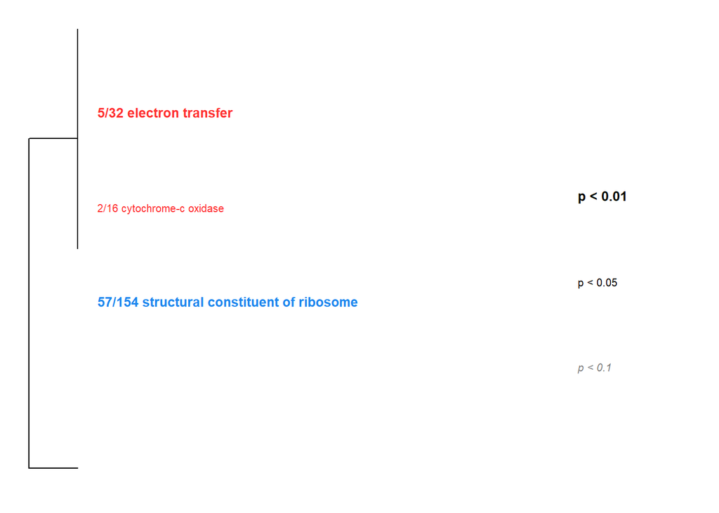

```
## GO terms dispayed:  3
## "Good genes" accounted for:  62 out of 382 ( 16% )
```

```r
# do not continue if the printout shows that no GO terms pass 10% FDR.


# Plotting results
results=gomwuPlot(input,goAnnotations,goDivision,
#   absValue=-log(0.05,10),  # genes with the measure value exceeding this will be counted as "good genes". Specify absValue=0.001 if you are doing Fisher's exact test for standard GO enrichment or analyzing a WGCNA module (all non-zero genes = "good genes").
    absValue=1,
    level1=0.1, # FDR threshold for plotting. Specify level1=1 to plot all GO categories containing genes exceeding the absValue.
    level2=0.05, # FDR cutoff to print in regular (not italic) font.
    level3=0.01, # FDR cutoff to print in large bold font.
    txtsize=1.2,    # decrease to fit more on one page, or increase (after rescaling the plot so the tree fits the text) for better "word cloud" effect
    treeHeight=0.5, # height of the hierarchical clustering tree
#   colors=c("dodgerblue2","firebrick1","skyblue2","lightcoral") # these are default colors, un-remar and change if needed
)
```

```r
# manually rescale the plot so the tree matches the text
# if there are too many categories displayed, try make it more stringent with level1=0.05,level2=0.01,level3=0.001.

# text representation of results, with actual adjusted p-values
results
```

```
##                                                  pval direction
## 57/154 structural constituent of ribosome 0.001292984         0
## 2/16 cytochrome-c oxidase activity        0.029371361         1
## 5/32 electron transfer activity           0.001608640         1
##                                                 color
## 57/154 structural constituent of ribosome dodgerblue2
## 2/16 cytochrome-c oxidase activity         firebrick1
## 5/32 electron transfer activity            firebrick1
```

```r
#GO enrichment analysis
#Hour 4

#######BP
#No significant GO terms
```

```r
#GO enrichment analysis
#Hour 4

#######CC
goDivision="CC" # either MF, or BP, or CC

gomwuStats(input, goDatabase, goAnnotations, goDivision,
           perlPath="perl",
           largest=0.1,
           smallest=5,
           clusterCutHeight=0.25
)
```

```
## Continuous measure of interest: will perform MWU test
## 9  GO terms at 10% FDR
```

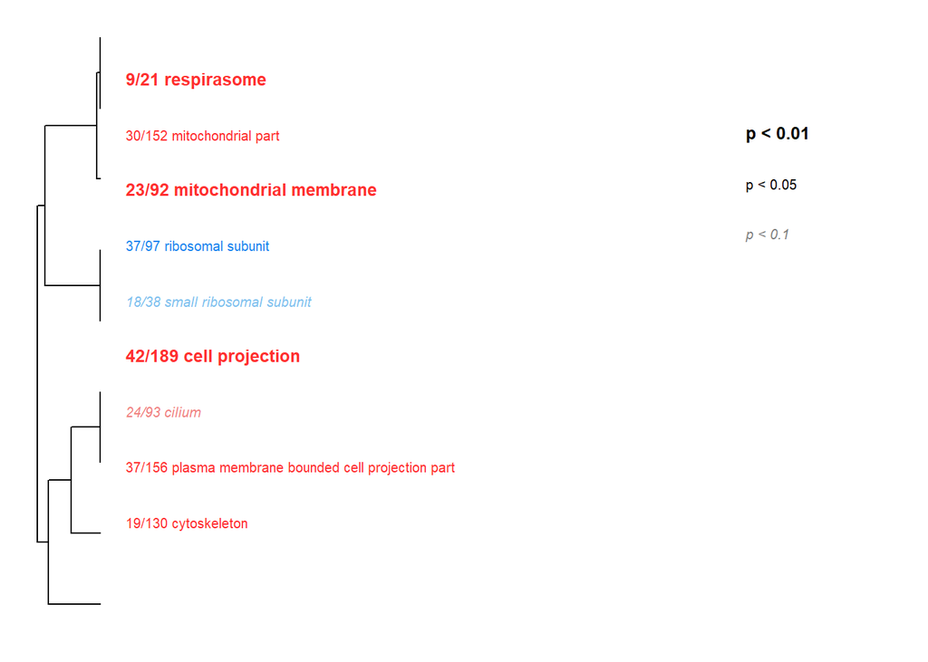

```
## GO terms dispayed:  9
## "Good genes" accounted for:  123 out of 416 ( 30% )
```

```r
# Plotting results
results=gomwuPlot(input,goAnnotations,goDivision,
                  absValue=1,
                  level1=0.1,
                  level2=0.05,
                  level3=0.01,
                  txtsize=1.2,
                  treeHeight=0.5
)
```

```r
# text representation of results, with actual adjusted p-values
results
```

```
##                                                             pval direction
## 19/130 cytoskeleton                                 0.0485716399         1
## 37/156 plasma membrane bounded cell projection part 0.0487910735         1
## 24/93 cilium                                        0.0580142940         1
## 42/189 cell projection                              0.0009763461         1
## 18/38 small ribosomal subunit                       0.0614516619         0
## 37/97 ribosomal subunit                             0.0336106673         0
## 23/92 mitochondrial membrane                        0.0009763461         1
## 30/152 mitochondrial part                           0.0485716399         1
## 9/21 respirasome                                    0.0003353142         1
##                                                           color
## 19/130 cytoskeleton                                  firebrick1
## 37/156 plasma membrane bounded cell projection part  firebrick1
## 24/93 cilium                                         lightcoral
## 42/189 cell projection                               firebrick1
## 18/38 small ribosomal subunit                          skyblue2
## 37/97 ribosomal subunit                             dodgerblue2
## 23/92 mitochondrial membrane                         firebrick1
## 30/152 mitochondrial part                            firebrick1
## 9/21 respirasome                                     firebrick1
```

```r
#GO enrichment analysis
#Hour 10

#######MF
input="b37_7.5.10_rec_GO.csv"
goDivision="MF" # either MF, or BP, or CC

gomwuStats(input, goDatabase, goAnnotations, goDivision,
           perlPath="perl",
           largest=0.1,
           smallest=5,
           clusterCutHeight=0.25
)
```

```
## Continuous measure of interest: will perform MWU test
## 13  GO terms at 10% FDR
```

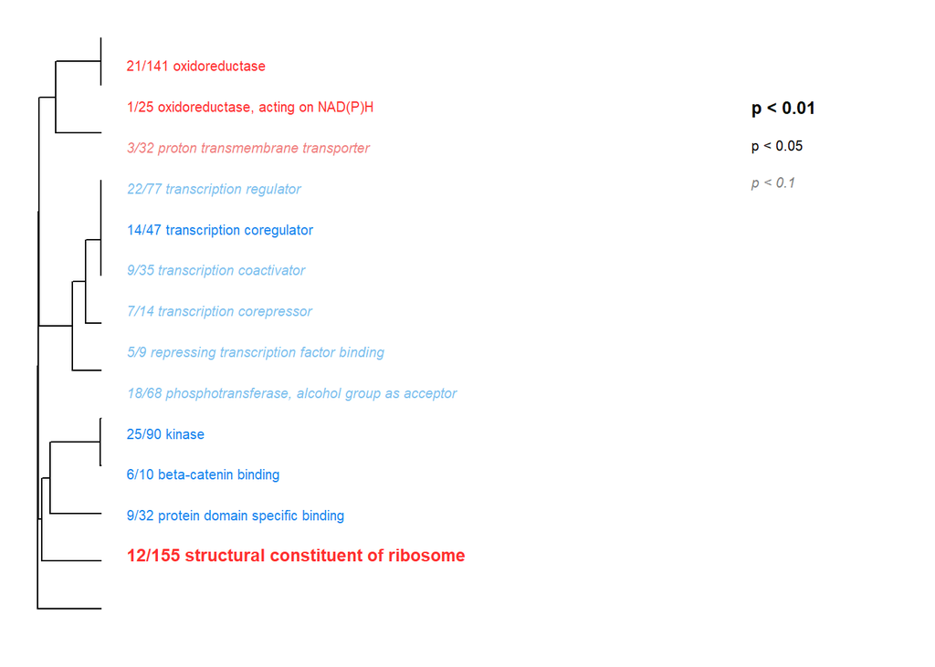

```
## GO terms dispayed:  13
## "Good genes" accounted for:  91 out of 349 ( 26% )
```

```r
# Plotting results
results=gomwuPlot(input,goAnnotations,goDivision,
                  absValue=1,
                  level1=0.1,
                  level2=0.05,
                  level3=0.01,
                  txtsize=1.2,
                  treeHeight=0.5
)
```

```r
# text representation of results, with actual adjusted p-values
results
```

```
##                                                                     pval
## 12/155 structural constituent of ribosome                    0.002312533
## 9/32 protein domain specific binding                         0.045431815
## 6/10 beta-catenin binding                                    0.045431815
## 25/90 kinase activity                                        0.045431815
## 18/68 phosphotransferase activity, alcohol group as acceptor 0.077740038
## 5/9 repressing transcription factor binding                  0.087341743
## 7/14 transcription corepressor activity                      0.098658308
## 9/35 transcription coactivator activity                      0.098658308
## 14/47 transcription coregulator activity                     0.019737068
## 22/77 transcription regulator activity                       0.087341743
## 3/32 proton transmembrane transporter activity               0.087341743
## 1/25 oxidoreductase activity, acting on NAD(P)H              0.039056708
## 21/141 oxidoreductase activity                               0.019737068
##                                                              direction
## 12/155 structural constituent of ribosome                            1
## 9/32 protein domain specific binding                                 0
## 6/10 beta-catenin binding                                            0
## 25/90 kinase activity                                                0
## 18/68 phosphotransferase activity, alcohol group as acceptor         0
## 5/9 repressing transcription factor binding                          0
## 7/14 transcription corepressor activity                              0
## 9/35 transcription coactivator activity                              0
## 14/47 transcription coregulator activity                             0
## 22/77 transcription regulator activity                               0
## 3/32 proton transmembrane transporter activity                       1
## 1/25 oxidoreductase activity, acting on NAD(P)H                      1
## 21/141 oxidoreductase activity                                       1
##                                                                    color
## 12/155 structural constituent of ribosome                     firebrick1
## 9/32 protein domain specific binding                         dodgerblue2
## 6/10 beta-catenin binding                                    dodgerblue2
## 25/90 kinase activity                                        dodgerblue2
## 18/68 phosphotransferase activity, alcohol group as acceptor    skyblue2
## 5/9 repressing transcription factor binding                     skyblue2
## 7/14 transcription corepressor activity                         skyblue2
## 9/35 transcription coactivator activity                         skyblue2
## 14/47 transcription coregulator activity                     dodgerblue2
## 22/77 transcription regulator activity                          skyblue2
## 3/32 proton transmembrane transporter activity                lightcoral
## 1/25 oxidoreductase activity, acting on NAD(P)H               firebrick1
## 21/141 oxidoreductase activity                                firebrick1
```

```r
#GO enrichment analysis
#Hour 10

#######BP
goDivision="BP" # either MF, or BP, or CC

gomwuStats(input, goDatabase, goAnnotations, goDivision,
           perlPath="perl",
           largest=0.1,
           smallest=5,
           clusterCutHeight=0.25
)
```

```
## Continuous measure of interest: will perform MWU test
## 17  GO terms at 10% FDR
```

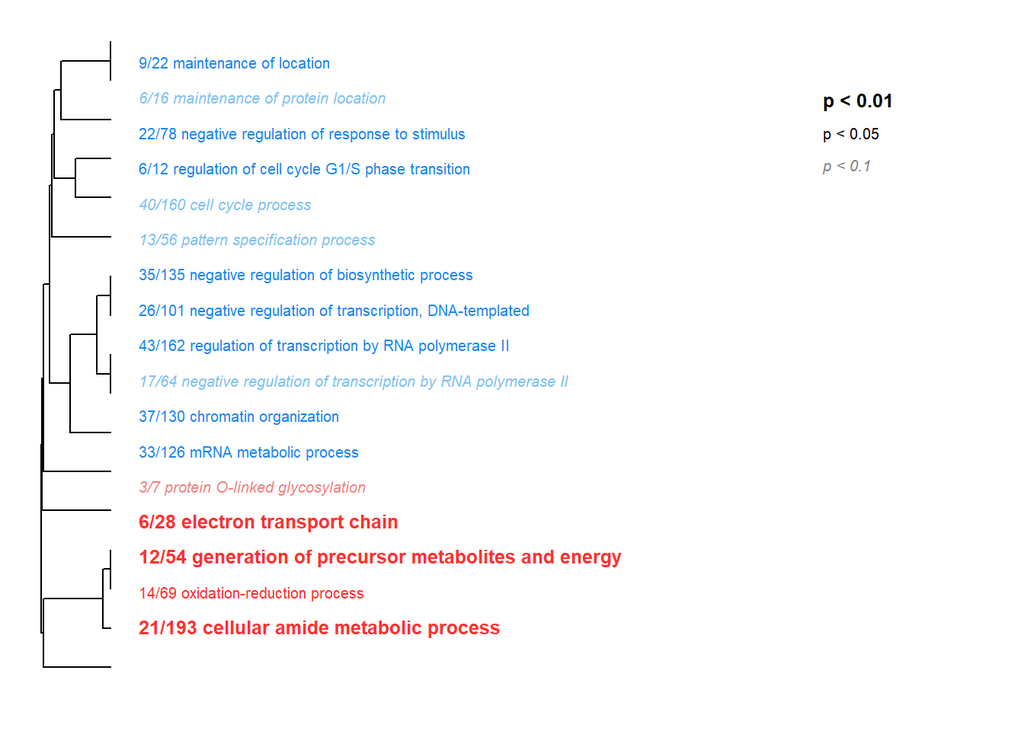

```
## GO terms dispayed:  17
## "Good genes" accounted for:  195 out of 423 ( 46% )
```

```r
# Plotting results
results=gomwuPlot(input,goAnnotations,goDivision,
                  absValue=1,
                  level1=0.1,
                  level2=0.05,
                  level3=0.01,
                  txtsize=1.2,
                  treeHeight=0.5
)
```

```r
# text representation of results, with actual adjusted p-values
results
```

```
##                                                                        pval
## 21/193 cellular amide metabolic process                         0.003535126
## 14/69 oxidation-reduction process                               0.024078124
## 12/54 generation of precursor metabolites and energy            0.004196370
## 6/28 electron transport chain                                   0.004196370
## 3/7 protein O-linked glycosylation                              0.076675947
## 33/126 mRNA metabolic process                                   0.024078124
## 37/130 chromatin organization                                   0.024943531
## 17/64 negative regulation of transcription by RNA polymerase II 0.088058091
## 43/162 regulation of transcription by RNA polymerase II         0.034543598
## 26/101 negative regulation of transcription, DNA-templated      0.048562093
## 35/135 negative regulation of biosynthetic process              0.024078124
## 13/56 pattern specification process                             0.088058091
## 40/160 cell cycle process                                       0.088058091
## 6/12 regulation of cell cycle G1/S phase transition             0.039344937
## 22/78 negative regulation of response to stimulus               0.024078124
## 6/16 maintenance of protein location                            0.088058091
## 9/22 maintenance of location                                    0.024078124
##                                                                 direction
## 21/193 cellular amide metabolic process                                 1
## 14/69 oxidation-reduction process                                       1
## 12/54 generation of precursor metabolites and energy                    1
## 6/28 electron transport chain                                           1
## 3/7 protein O-linked glycosylation                                      1
## 33/126 mRNA metabolic process                                           0
## 37/130 chromatin organization                                           0
## 17/64 negative regulation of transcription by RNA polymerase II         0
## 43/162 regulation of transcription by RNA polymerase II                 0
## 26/101 negative regulation of transcription, DNA-templated              0
## 35/135 negative regulation of biosynthetic process                      0
## 13/56 pattern specification process                                     0
## 40/160 cell cycle process                                               0
## 6/12 regulation of cell cycle G1/S phase transition                     0
## 22/78 negative regulation of response to stimulus                       0
## 6/16 maintenance of protein location                                    0
## 9/22 maintenance of location                                            0
##                                                                       color
## 21/193 cellular amide metabolic process                          firebrick1
## 14/69 oxidation-reduction process                                firebrick1
## 12/54 generation of precursor metabolites and energy             firebrick1
## 6/28 electron transport chain                                    firebrick1
## 3/7 protein O-linked glycosylation                               lightcoral
## 33/126 mRNA metabolic process                                   dodgerblue2
## 37/130 chromatin organization                                   dodgerblue2
## 17/64 negative regulation of transcription by RNA polymerase II    skyblue2
## 43/162 regulation of transcription by RNA polymerase II         dodgerblue2
## 26/101 negative regulation of transcription, DNA-templated      dodgerblue2
## 35/135 negative regulation of biosynthetic process              dodgerblue2
## 13/56 pattern specification process                                skyblue2
## 40/160 cell cycle process                                          skyblue2
## 6/12 regulation of cell cycle G1/S phase transition             dodgerblue2
## 22/78 negative regulation of response to stimulus               dodgerblue2
## 6/16 maintenance of protein location                               skyblue2
## 9/22 maintenance of location                                    dodgerblue2
```

```r
#GO enrichment analysis
#Hour 10

#######CC
goDivision="CC" # either MF, or BP, or CC

gomwuStats(input, goDatabase, goAnnotations, goDivision,
           perlPath="perl",
           largest=0.1,
           smallest=5,
           clusterCutHeight=0.25
)
```

```
## Continuous measure of interest: will perform MWU test
## 11  GO terms at 10% FDR
```

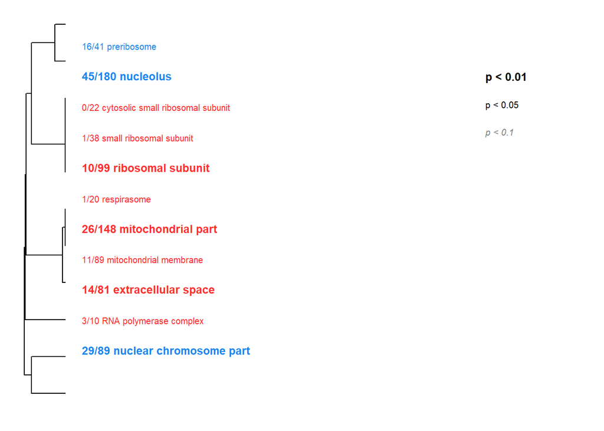

```
## GO terms dispayed:  11
## "Good genes" accounted for:  110 out of 393 ( 28% )
```

```r
# Plotting results
results=gomwuPlot(input,goAnnotations,goDivision,
                  absValue=1,
                  level1=0.1,
                  level2=0.05,
                  level3=0.01,
                  txtsize=1.2,
                  treeHeight=0.5
)
```

```r
# text representation of results, with actual adjusted p-values
results
```

```
##                                               pval direction       color
## 29/89 nuclear chromosome part          0.008200050         0 dodgerblue2
## 3/10 RNA polymerase complex            0.030760353         1  firebrick1
## 14/81 extracellular space              0.008200050         1  firebrick1
## 11/89 mitochondrial membrane           0.010957436         1  firebrick1
## 26/148 mitochondrial part              0.009951337         1  firebrick1
## 1/20 respirasome                       0.047749966         1  firebrick1
## 10/99 ribosomal subunit                0.008200050         1  firebrick1
## 1/38 small ribosomal subunit           0.011911375         1  firebrick1
## 0/22 cytosolic small ribosomal subunit 0.044354266         1  firebrick1
## 45/180 nucleolus                       0.008200050         0 dodgerblue2
## 16/41 preribosome                      0.044354266         0 dodgerblue2
```

```r
#GO enrichment analysis
#Hour 24

#######MF
# Edit these to match your data file names:
input="b37_7.5.24_rec_GO.csv"
goDivision="MF" # either MF, or BP, or CC

gomwuStats(input, goDatabase, goAnnotations, goDivision,
           perlPath="perl",
           largest=0.1,
           smallest=5,
           clusterCutHeight=0.25
)
```

```
## Continuous measure of interest: will perform MWU test
## 6  GO terms at 10% FDR
```

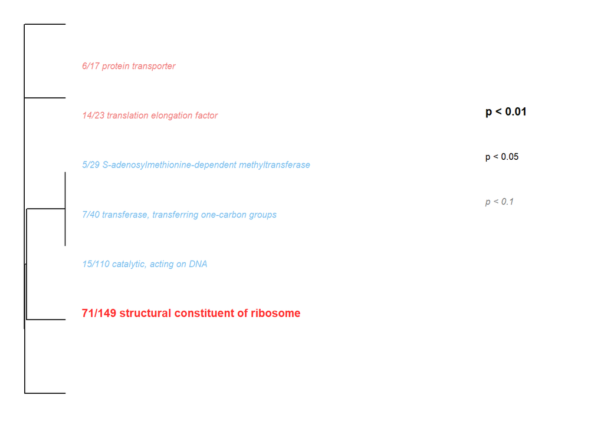

```
## GO terms dispayed:  6
## "Good genes" accounted for:  111 out of 408 ( 27% )
```

```r
# Plotting results
results=gomwuPlot(input,goAnnotations,goDivision,
                  absValue=1,
                  level1=0.1,
                  level2=0.05,
                  level3=0.01,
                  txtsize=1.2,
                  treeHeight=0.5
)
```

```r
# text representation of results, with actual adjusted p-values
results
```

```
##                                                                        pval
## 71/149 structural constituent of ribosome                      3.996484e-14
## 15/110 catalytic activity, acting on DNA                       8.856420e-02
## 7/40 transferase activity, transferring one-carbon groups      8.856420e-02
## 5/29 S-adenosylmethionine-dependent methyltransferase activity 8.856420e-02
## 14/23 translation elongation factor activity                   8.856420e-02
## 6/17 protein transporter activity                              8.856420e-02
##                                                                direction
## 71/149 structural constituent of ribosome                              1
## 15/110 catalytic activity, acting on DNA                               0
## 7/40 transferase activity, transferring one-carbon groups              0
## 5/29 S-adenosylmethionine-dependent methyltransferase activity         0
## 14/23 translation elongation factor activity                           1
## 6/17 protein transporter activity                                      1
##                                                                     color
## 71/149 structural constituent of ribosome                      firebrick1
## 15/110 catalytic activity, acting on DNA                         skyblue2
## 7/40 transferase activity, transferring one-carbon groups        skyblue2
## 5/29 S-adenosylmethionine-dependent methyltransferase activity   skyblue2
## 14/23 translation elongation factor activity                   lightcoral
## 6/17 protein transporter activity                              lightcoral
```

```r
#GO enrichment analysis
#Hour 24

#######BP
#No significant GO terms
```

```r
#GO enrichment analysis
#Hour 24

#######CC
goDivision="CC" # either MF, or BP, or CC

gomwuStats(input, goDatabase, goAnnotations, goDivision,
           perlPath="perl",
           largest=0.1,
           smallest=5,
           clusterCutHeight=0.25
)
```

```
## Continuous measure of interest: will perform MWU test
## 7  GO terms at 10% FDR
```

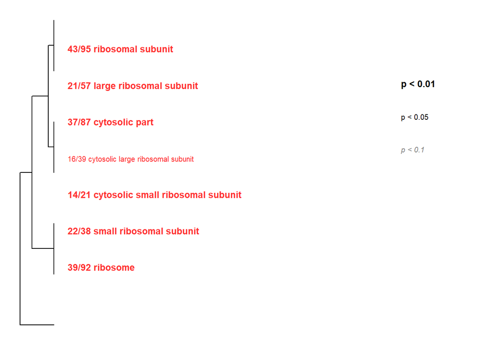

```
## GO terms dispayed:  7
## "Good genes" accounted for:  81 out of 426 ( 19% )
```

```r
# Plotting results
results=gomwuPlot(input,goAnnotations,goDivision,
                  absValue=1,
                  level1=0.1,
                  level2=0.05,
                  level3=0.01,
                  txtsize=1.2,
                  treeHeight=0.5,
                  colors=c("dodgerblue2","firebrick1","skyblue2","lightcoral")
)
```

```r
# text representation of results, with actual adjusted p-values
results
```

```
##                                                 pval direction      color
## 39/92 ribosome                          2.358865e-06         1 firebrick1
## 22/38 small ribosomal subunit           1.678686e-03         1 firebrick1
## 14/21 cytosolic small ribosomal subunit 6.977345e-03         1 firebrick1
## 16/39 cytosolic large ribosomal subunit 1.343071e-02         1 firebrick1
## 37/87 cytosolic part                    2.264307e-05         1 firebrick1
## 21/57 large ribosomal subunit           1.149482e-03         1 firebrick1
## 43/95 ribosomal subunit                 3.452794e-07         1 firebrick1
```

```r
#GO enrichment analysis
#Hour 48

#######MF
# Edit these to match your data file names:
input="b37_7.5.48_rec_GO.csv"
goDivision="MF" # either MF, or BP, or CC

gomwuStats(input, goDatabase, goAnnotations, goDivision,
           perlPath="perl",
           largest=0.1,
           smallest=5,
           clusterCutHeight=0.25
)
```

```
## Continuous measure of interest: will perform MWU test
## 32  GO terms at 10% FDR
```

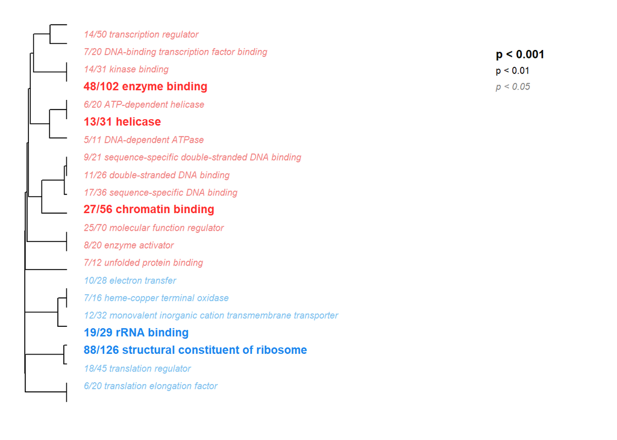

```
## GO terms dispayed:  21
## "Good genes" accounted for:  233 out of 456 ( 51% )
```

```r
# Plotting results
results=gomwuPlot(input,goAnnotations,goDivision,
                  absValue=1,
                  level1=0.05,
                  level2=0.01,
                  level3=0.001,
                  txtsize=1.2,
                  treeHeight=0.5
)
```

```r
# text representation of results, with actual adjusted p-values
results
```

```
##                                                                              pval
## 6/20 translation elongation factor activity                          4.314532e-02
## 18/45 translation regulator activity                                 4.960644e-02
## 88/126 structural constituent of ribosome                            1.000000e-15
## 19/29 rRNA binding                                                   7.894386e-06
## 12/32 monovalent inorganic cation transmembrane transporter activity 4.823352e-02
## 7/16 heme-copper terminal oxidase activity                           4.823352e-02
## 10/28 electron transfer activity                                     4.823352e-02
## 7/12 unfolded protein binding                                        4.823352e-02
## 8/20 enzyme activator activity                                       3.887760e-02
## 25/70 molecular function regulator                                   3.887760e-02
## 27/56 chromatin binding                                              3.900354e-04
## 17/36 sequence-specific DNA binding                                  2.271716e-02
## 11/26 double-stranded DNA binding                                    2.271716e-02
## 9/21 sequence-specific double-stranded DNA binding                   3.887760e-02
## 5/11 DNA-dependent ATPase activity                                   3.887760e-02
## 13/31 helicase activity                                              3.900354e-04
## 6/20 ATP-dependent helicase activity                                 4.823352e-02
## 48/102 enzyme binding                                                3.195103e-05
## 14/31 kinase binding                                                 2.706123e-02
## 7/20 DNA-binding transcription factor binding                        4.823352e-02
## 14/50 transcription regulator activity                               1.638065e-02
##                                                                      direction
## 6/20 translation elongation factor activity                                  0
## 18/45 translation regulator activity                                         0
## 88/126 structural constituent of ribosome                                    0
## 19/29 rRNA binding                                                           0
## 12/32 monovalent inorganic cation transmembrane transporter activity         0
## 7/16 heme-copper terminal oxidase activity                                   0
## 10/28 electron transfer activity                                             0
## 7/12 unfolded protein binding                                                1
## 8/20 enzyme activator activity                                               1
## 25/70 molecular function regulator                                           1
## 27/56 chromatin binding                                                      1
## 17/36 sequence-specific DNA binding                                          1
## 11/26 double-stranded DNA binding                                            1
## 9/21 sequence-specific double-stranded DNA binding                           1
## 5/11 DNA-dependent ATPase activity                                           1
## 13/31 helicase activity                                                      1
## 6/20 ATP-dependent helicase activity                                         1
```

[output cut: 11 more lines]

```
## 10/28 electron transfer activity                                        skyblue2
## 7/12 unfolded protein binding                                         lightcoral
## 8/20 enzyme activator activity                                        lightcoral
## 25/70 molecular function regulator                                    lightcoral
## 27/56 chromatin binding                                               firebrick1
## 17/36 sequence-specific DNA binding                                   lightcoral
## 11/26 double-stranded DNA binding                                     lightcoral
## 9/21 sequence-specific double-stranded DNA binding                    lightcoral
## 5/11 DNA-dependent ATPase activity                                    lightcoral
## 13/31 helicase activity                                               firebrick1
## 6/20 ATP-dependent helicase activity                                  lightcoral
## 48/102 enzyme binding                                                 firebrick1
## 14/31 kinase binding                                                  lightcoral
## 7/20 DNA-binding transcription factor binding                         lightcoral
## 14/50 transcription regulator activity                                lightcoral
```

```r
#GO enrichment analysis
#Hour 48

#######BP
goDivision="BP" # either MF, or BP, or CC

gomwuStats(input, goDatabase, goAnnotations, goDivision,
           perlPath="perl",
           largest=0.1,
           smallest=5,
           clusterCutHeight=0.25
)
```

```
## Continuous measure of interest: will perform MWU test
## 44  GO terms at 10% FDR
```

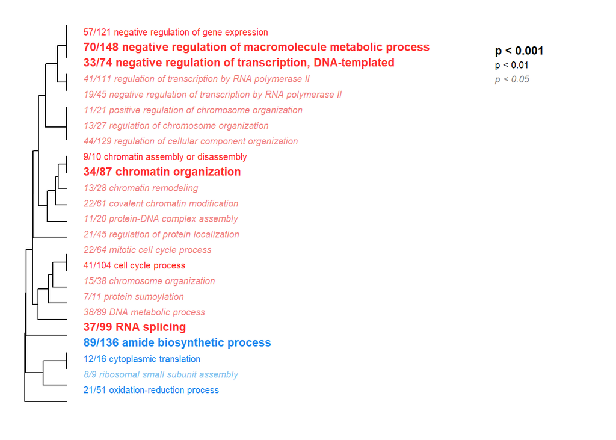

```
## GO terms dispayed:  24
## "Good genes" accounted for:  297 out of 523 ( 57% )
```

```r
# Plotting results
results=gomwuPlot(input,goAnnotations,goDivision,
                  absValue=1,
                  level1=0.05,
                  level2=0.01,
                  level3=0.001,
                  txtsize=1.2,
                  treeHeight=0.5
)
```